# exercise D

Statistical Analysis

Author

Jaykumar Patel

Published

April 11, 2025

# Step one: Description of data

To get started, I prompt GPT-4o with what I am trying to do (statistical analysis), and ideas on how I can achieve that. Additionally, I attach the `amesHousing2011doc.txt` file so that GPT-4o has context regarding the dataset.

## Ask GPT-4o for Initial Ideas

### Prompt

I have the Ames Housing Dataset. I want to perform some analysis where I gather statistics and and graphics describing the individual variables (the columns) and the relationships between pairs of variables (the columns).

Firstly, can I get ideas on what kind of analysis I can do? I have also attached a `amesHousing2011doc.txt` file, which provides descriptions of the columns and their values in the dataset.

### Response

```
Great! The Ames Housing dataset is very rich and well-suited for exploratory data analysis (EDA), regression modeling, and feature engineering. Given the wide mix of variable types (nominal, ordinal, discrete, continuous), you can explore it from multiple perspectives. Here are ideas for the kinds o…

---

## 🟦 **Univariate Analysis** (Individual Columns)

### ✳️ Categorical Variables (Nominal/Ordinal)
- **Frequency counts** for values (e.g. `MS Zoning`, `Neighborhood`, `House Style`)
- **Bar plots** of category distributions
- **Mode** (most common category)
- **Missing values** analysis (e.g. `Pool QC`, `Fence`, `Alley`)

### ✳️ Numerical Variables (Continuous/Discrete)
- **Summary statistics** (mean, median, std, min, max, percentiles)
- **Histograms** and **KDE plots**
- **Boxplots** for outlier detection
- **Missing data patterns**
- **Distribution skews** (e.g., is `SalePrice` right-skewed?)

---

## 🟨 **Bivariate Analysis** (Column vs. Column)

### ✳️ Numerical vs Numerical
- **Scatter plots** (e.g., `Gr Liv Area` vs. `SalePrice`)
- **Correlation matrix / heatmap**
- **Linearity checks** (especially for regression)
- **SalePrice vs. total basement square footage, garage area, etc.**

### ✳️ Categorical vs Numerical
- **Box plots** or **violin plots** (e.g., `Neighborhood` vs `SalePrice`)
- **Groupby mean/median plots** (e.g., average `SalePrice` by `House Style`)
- **ANOVA** tests for statistical significance

### ✳️ Categorical vs Categorical
- **Cross-tabulations** (e.g., `Bldg Type` vs `House Style`)
- **Stacked bar charts** or **mosaic plots**

---

```

[output cut: 21 more lines]

```
- **Handle missing values** (mean/median imputation or special category)

---

## 🔎 Specific Questions You Could Explore

- Which neighborhoods have the highest median house prices?
- Do houses with basements or garages tend to sell for more?
- Does the quality rating of kitchens or exterior correlate with price?
- How does remodel year affect house price?
- Is there evidence of seasonality in the sales (`Mo Sold` vs `SalePrice`)?

---

If you'd like, I can help generate specific visualizations or code for some of these. Would you like to start by exploring individual variables, or jump into some bivariate analysis (like how `SalePrice` relates to others)?
```

## Determine Cloumns to Analyze

First, I will determine which columns I should analyze, because not all columns are important in predicting the house price. I will do this using 2 approaches.

### Approach 1

I will look at the `amesHousing2011doc.txt` and `amesHousing2011.csv` data manually to determine the important columns. I will also use my personal knowledge to determine which columns are useful.

The columns I determined to be useful are:

- MSSubClass - The type of dwelling can be important in determining the price of a house. Particularly, the age and number of floors are important.
- Neighborhood - House prices can vary by neighborhood depending on the available amenities, location, access to major roads, etc.
- BldgType - The price can vary by type of building. For example, a Duplex may be cheaper than a Single Family Detached home.
- HouseStyle - Whether the house is finished or unfinished and the number of stories it can can impact its price.
- OverallQual and OverallCond - This can point to the quality and condition of the building. Quality and conditional of the building is directly correlated with the price.
- GrLivArea - This captures the square footage of the house above ground. The square feet of the house is directly correlated with the price.
- BedroomAbvGr, FullBath, and HalfBath - The count of bedrooms and bathrooms is directly correlated with the price.
- GarageArea - This number not only indirectly captures the number of cars that can fit in the garage, but also indicates potential storage space. I suspect that people like a large garage for that additional storage space. This could help indicate the price.
- PoolArea - Houses that have pools are more expensive than those that don’t. Thus, this could be useful in determining house price.

### Approach 2

I will ask GPT-4o to determine which columns are important by passing it the `amesHousing2011doc.txt` and `amesHousing2011.csv` as context. I hope that this context helps GPT-4o determine which columns are important in determining house prices.

#### Prompt

I have uploaded 2 files. One is `amesHousing2011.csv` which contains data about houses - along with their feature (columns) and price data. The other file is `amesHousing2011doc.txt` which provides descriptions for each of the columns.

I want to create a regression model to predict house prices given a set of features. However, I don’t want to include all features, as all may not be important and may add unnecessary noise. Given the descriptions of the columns, can you give me a list (subset) of 10 columns that I should keep, along with short, 1 sentence descriptions as to why that column is important in helping predict the house prices?

Give your response in a bulleted list and keep your descriptions concise.

#### Response

```
Here are **10 important features** selected from the Ames Housing dataset, along with **brief explanations** for why they are useful in predicting house prices:

- **Gr Liv Area** *(Above ground living area in square feet)*
  Larger homes generally cost more; this is one of the most directly proportional indicators of value.

- **Overall Qual** *(Overall material and finish of the house)*
  Higher-quality construction and finishes typically result in higher sale prices.

- **Year Built** *(Original construction year)*
  Newer homes often require fewer repairs and may be more energy-efficient, increasing value.

- **Garage Cars** *(Garage capacity in terms of car spaces)*
  More garage space is a highly desirable feature for homeowners, impacting price positively.

- **KitchenQual** *(Kitchen quality)*
  The kitchen is a focal point in a home; better kitchen quality often significantly boosts appeal and value.

- **Total Bsmt SF** *(Total basement area)*
  A larger basement adds usable square footage, even if unfinished, which can increase value.

- **Neighborhood** *(Location within Ames city limits)*
  Location is a key driver in real estate; some neighborhoods command higher prices due to amenities, schools, etc.

- **Fireplaces** *(Number of fireplaces)*
  Fireplaces can enhance comfort and aesthetics, making a home more attractive to buyers.

- **Full Bath** *(Number of full bathrooms above grade)*
  More bathrooms support convenience and are highly valued in larger households.

- **Lot Area** *(Lot size in square feet)*
  Bigger lots provide more privacy and expansion potential, which can raise a property's market value.

Let me know if you'd like help preprocessing these features or building the model!
```

### Combining Approach 1 and Approach 2

When I combine the set of columns from Approach 1 and Approach 2 (by taking the union), I get these columns: `MSSubClass`, `Neighborhood`, `BldgType`, `HouseStyle`, `OverallQual`, `OverallCond`, `KitchenQual`, `BedroomAbvGr`, `HalfBath`, `FullBath`, `GarageArea`, `GarageCars`, `GrLivArea`, `TotalBsmtSF`, `LotArea`, `PoolArea`, `YearBuilt`, `Fireplaces`.

I will remove the column `Fireplaces` since it isn’t typically a priority for homeowners (from personal experience, which may be biased). I will also remove `OverallQual` since I believe that `OverallCond` may capture similar quality/condition information. Additionally, I will remove `LotArea` as I believe the living area square feet of the actual building, captured by `GrLivArea` and `TotalBsmtSF`, are more important. Finally, I will remove `GarageCars` as `GarageArea` indirectly captures how many cars can fit in it.

Thus, the final list of columns is: `MSSubClass`, `Neighborhood`, `BldgType`, `HouseStyle`, `OverallCond`, `KitchenQual`, `BedroomAbvGr`, `HalfBath`, `FullBath`, `GarageArea`, `GrLivArea`, `TotalBsmtSF`, `PoolArea`, `YearBuilt`.

### Determine Numerical and Categorical Columns

Firstly, I will determine which columns are Numerical and which are Categorical. I will do this by asking GPT-4o to write me a R script to do so.

#### Prompt

The `amesHousing2011.csv` file contains a database of house information, containing its features (columns) and prices. Some columns contain numerical data and some contain categorical data. Can you write me an R script that takes a list of column names, and prints which columns contain numerical data and which contain categorical data?

#### Response

```
Absolutely! Here's an R script that takes a list of column names and prints whether each column is **numerical** or **categorical**, based on the actual data types in the `amesHousing2011.csv` file.
```

```r
# Load required package
library(readr)
# Read the CSV file
df <- read_csv("amesHousing2011.csv")
# Define the list of column names you're interested in
selected_columns <- c(
  "MSSubClass",
  "Neighborhood",
  "BldgType",
  "HouseStyle",
  "OverallCond",
  "KitchenQual",
  "BedroomAbvGr",
  "HalfBath",
  "FullBath",
  "GarageArea",
  "GrLivArea",
  "TotalBsmtSF",
  "PoolArea",
  "YearBuilt"
)

# Check and print whether each selected column is numerical or categorical
for (col in selected_columns) {
  if (!col %in% colnames(df)) {
    cat(col, "is NOT found in the dataset.\n")
  } else {
    col_data <- df[[col]]
    if (is.numeric(col_data)) {
      cat(col, "- Numerical\n")
    } else if (is.character(col_data) || is.factor(col_data)) {
      cat(col, "- Categorical\n")
    } else {
      cat(col, "- Other type\n")
    }
  }
}
```

```
MSSubClass - Categorical
Neighborhood - Categorical
BldgType - Categorical
HouseStyle - Categorical
OverallCond - Numerical
KitchenQual - Categorical
BedroomAbvGr - Numerical
HalfBath - Numerical
FullBath - Numerical
GarageArea - Numerical
GrLivArea - Numerical
TotalBsmtSF - Numerical
PoolArea - Numerical
YearBuilt - Numerical
```

```
### How to use:
1. Save this script in a `.R` file.
2. Make sure the `amesHousing2011.csv` is in your working directory.
3. Run the script in R or RStudio.

Let me know if you want to convert categorical columns to factors or preprocess them for modeling too!
```

The numerical columns are: `OverallCond`, `BedroomAbvGr`, `HalfBath`, `FullBath`, `GarageArea`, `GrLivArea`, `TotalBsmtSF`, `PoolArea`, and `YearBuilt`.

The categorical columns are: `MSSubClass`, `Neighborhood`, `BldgType`, `HouseStyle`, and `KitchenQual`.

## Univariate Analysis

### Numerical Columns

The numerical columns are: `OverallCond`, `BedroomAbvGr`, `HalfBath`, `FullBath`, `GarageArea`, `GrLivArea`, `TotalBsmtSF`, `PoolArea`, and `YearBuilt`.

#### Visualizing Distribution of Values

I will start by visualizing the distribution of values for the numerical columns.

##### Prompt

Can you write an R script that generates distribution plots that help visualize the distribution of values? This R script should take a list of column names as input. The dataset is in `amesHousing2011.csv` file.

##### Response

```
Absolutely! Here's an R script that:

- Loads the data from `amesHousing2011.csv`
- Takes a list of column names
- Generates distribution plots (histograms with density curves) for each column
- Helps visualize variance by showing how spread out the values are
```

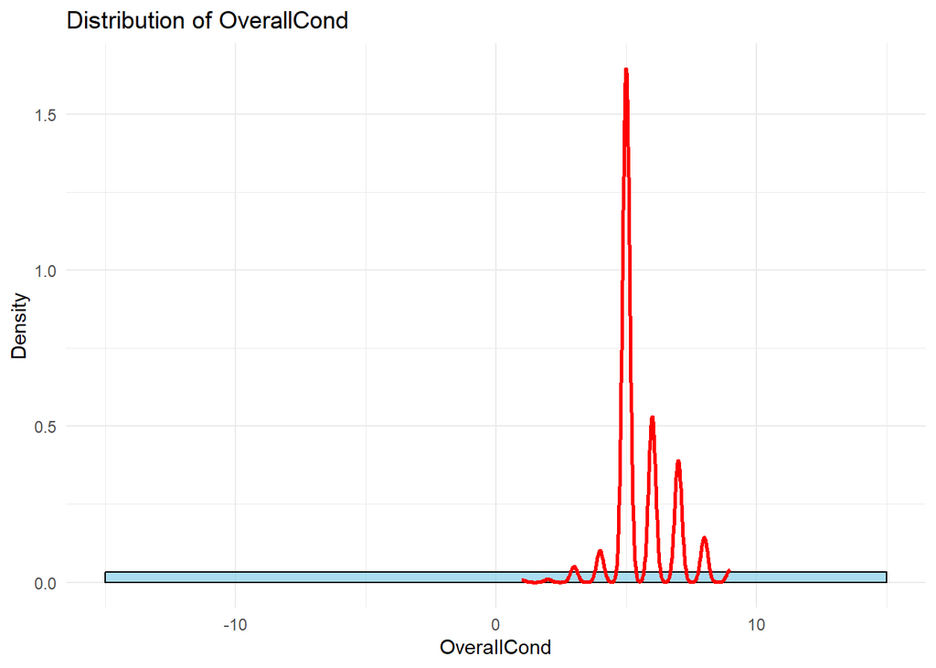

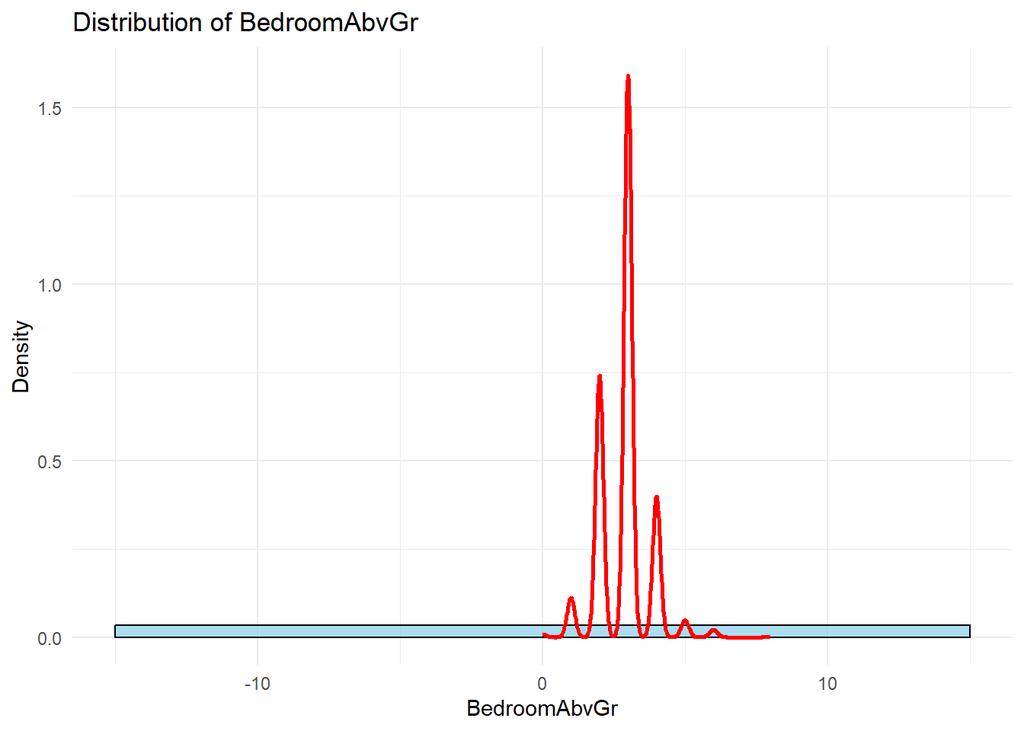

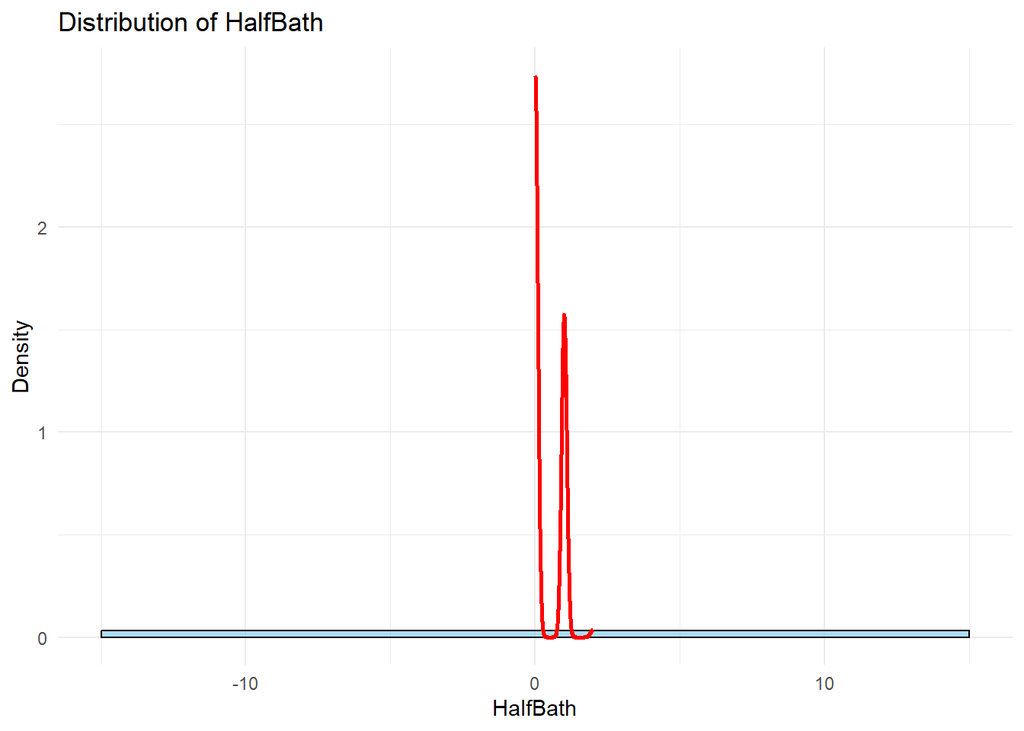

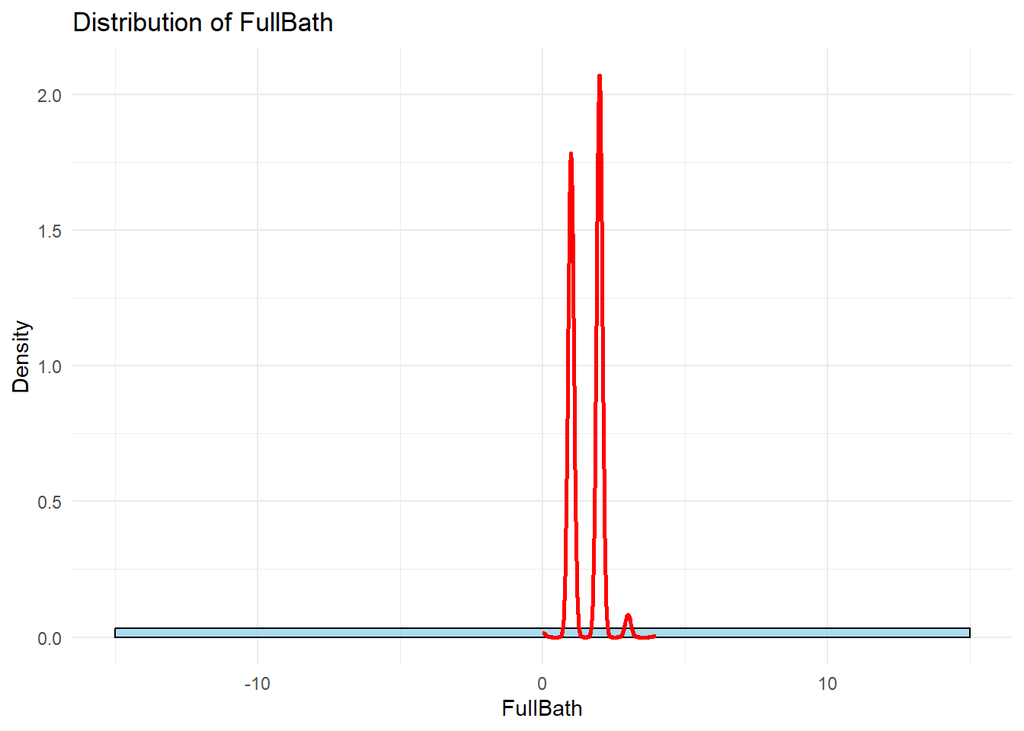

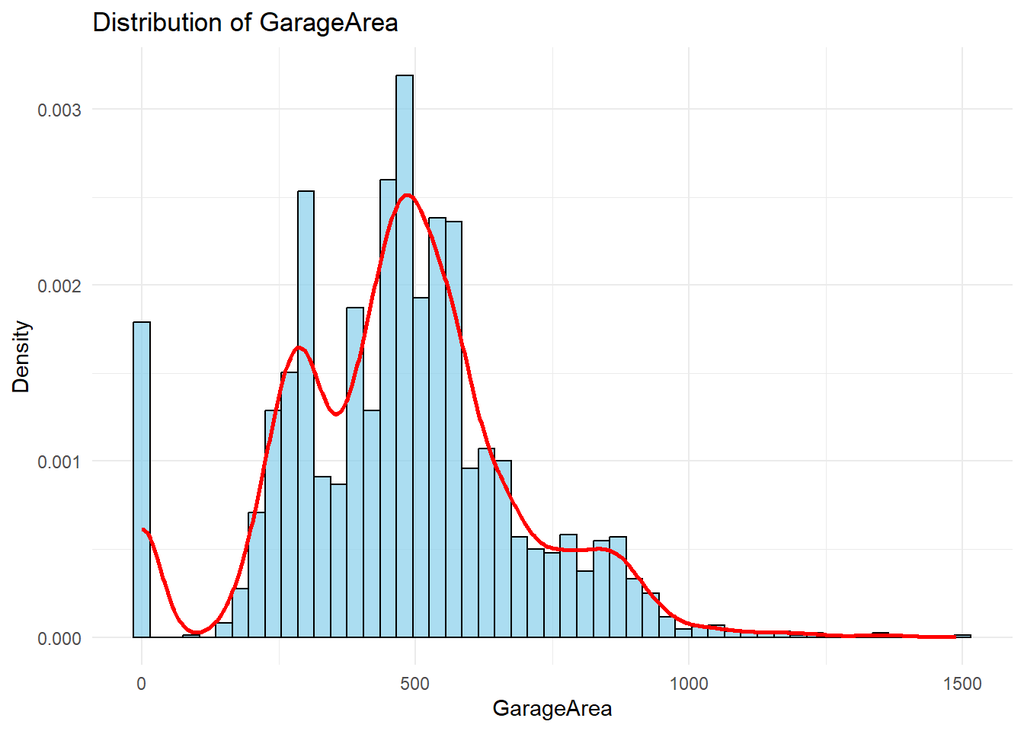

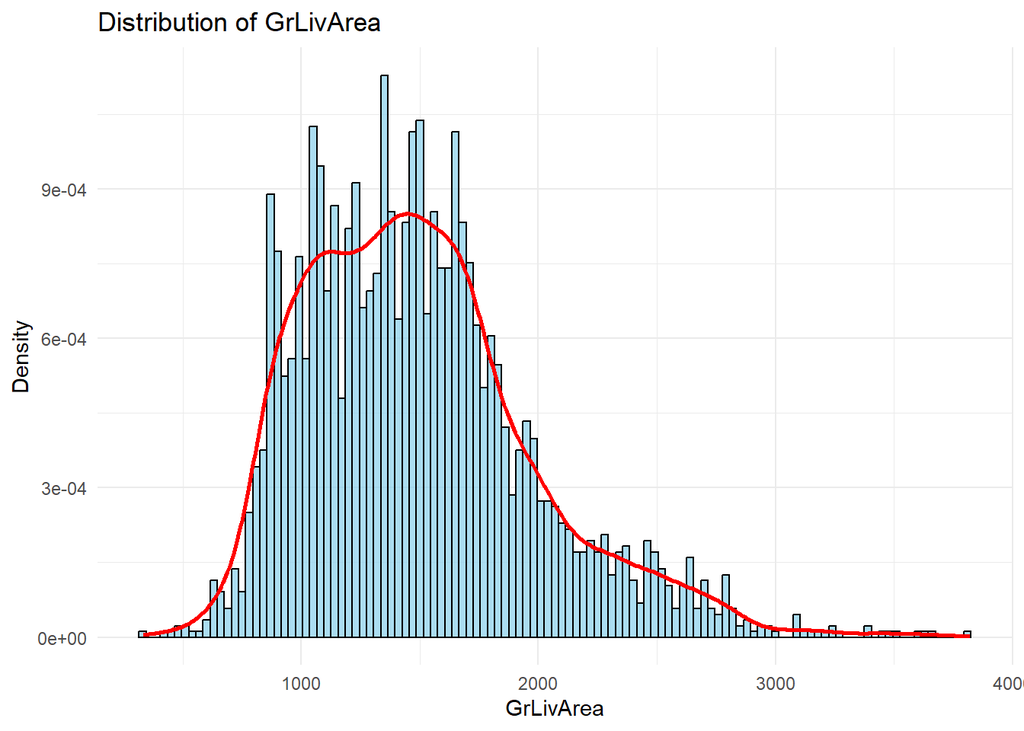

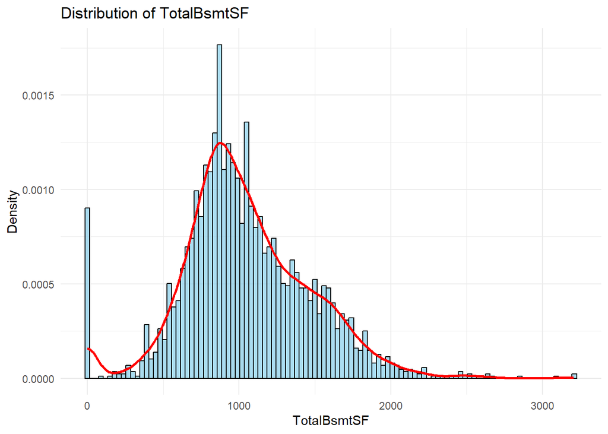

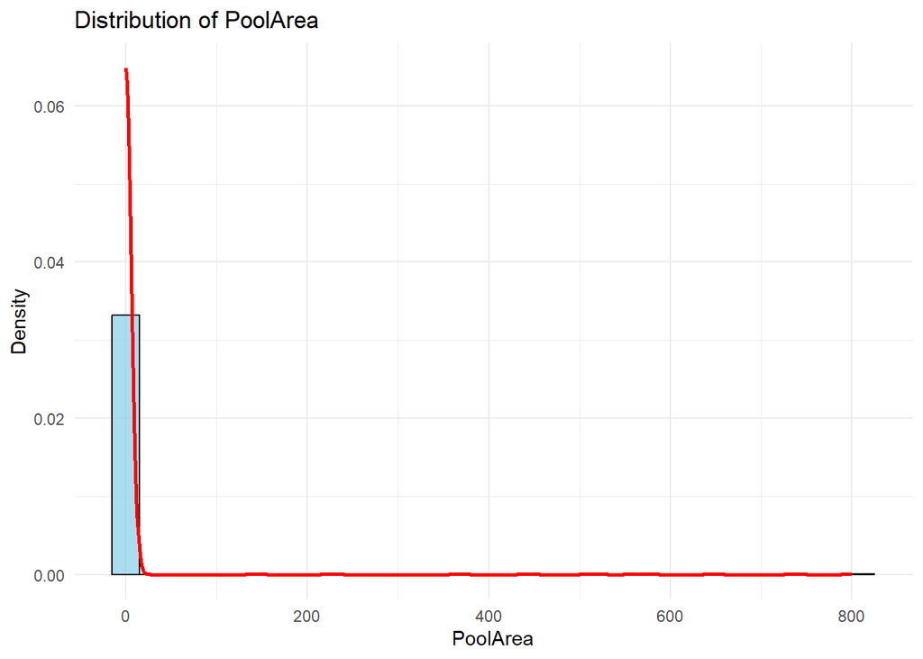

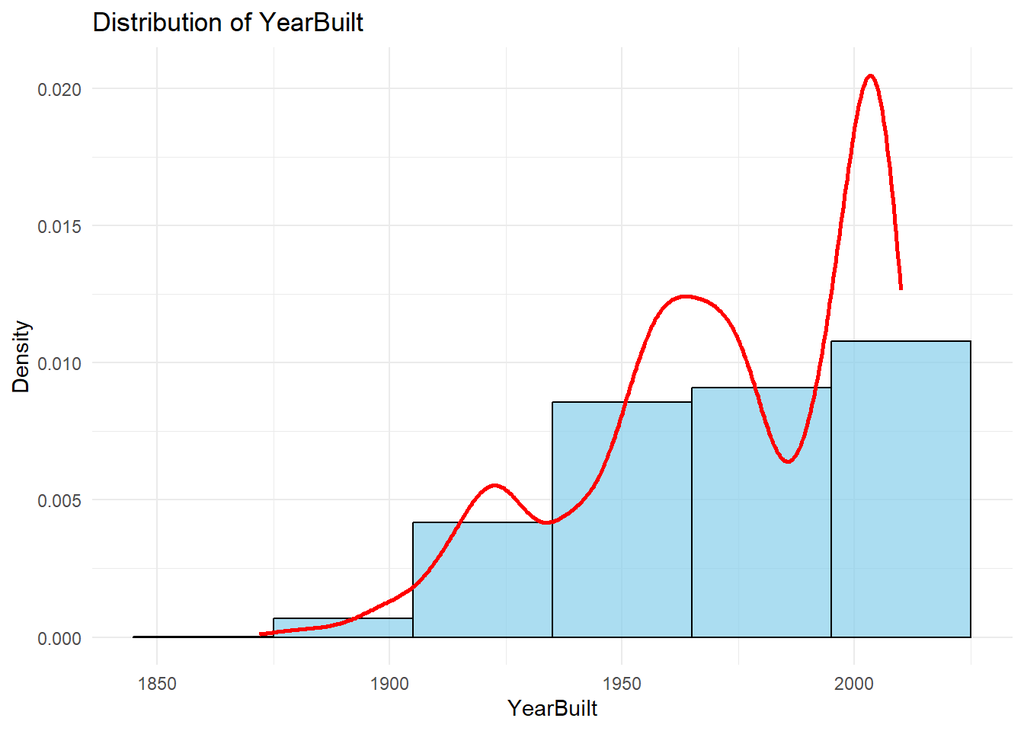

```r
# Load necessary libraries
library(readr)
library(ggplot2)
library(dplyr)
# Load the dataset
data <- read_csv("amesHousing2011.csv")
# Function to generate distribution plots for a list of numeric columns
plot_distributions <- function(data, columns) {
  for (col in columns) {
    if (is.numeric(data[[col]])) {
      print(
        ggplot(data, aes_string(x = col)) +
          geom_histogram(aes(y = ..density..), binwidth = 30, fill = "skyblue", color = "black", alpha = 0.7) +
          geom_density(color = "red", size = 1) +
          labs(
            title = paste("Distribution of", col),
            x = col,
            y = "Density"
          ) +
          theme_minimal()
      )
    } else {
      warning(paste("Skipping non-numeric column:", col))
    }
  }
}

# Example usage
columns_to_plot <- c("OverallCond", "BedroomAbvGr", "HalfBath", "FullBath", "GarageArea", "GrLivArea", "TotalBsmtSF", "PoolArea", "YearBuilt")
plot_distributions(data, columns_to_plot)
```

```
### What this does:
- For each numeric column, it plots a histogram overlaid with a smooth density curve.
- This gives a visual sense of how spread out (high or low variance) the data is.

Let me know if you want to arrange the plots in a grid layout or save them to files!
```

#### Getting numerical metrics

I’ll now getting some statistical information of numerical columns, such as mean, median, variance, and standard deviation.

##### Prompt

The charts are a little hard to interpret. I would like some concrete numerical data. Can you write me R code that determines the mean, median, variance, and standard deviation of a column. I want to pass a list of columns, and get the results for all the columns. The dataset is in `amesHousing2011.csv` file.

##### Response

```
Absolutely! Here's an R script that allows you to pass a **list of column names** and computes the **mean**, **median**, **variance**, and **standard deviation** for **each of them**, then outputs the results in a tidy table:
```

```r
# Load required libraries
library(readr)   # for reading CSV files
library(dplyr)   # for data manipulation
library(tibble)  # for tidy output
# Load the dataset
ames_data <- read_csv("amesHousing2011.csv")
# Define the columns you want to analyze
columns_to_analyze <- c("OverallCond", "BedroomAbvGr", "HalfBath", "FullBath",
                        "GarageArea", "GrLivArea", "TotalBsmtSF", "PoolArea", "YearBuilt")  # Change as needed

# Function to compute summary stats for one column
compute_stats <- function(df, col) {
  data <- df[[col]]
  tibble(
    Column = col,
    Mean = mean(data, na.rm = TRUE),
    Median = median(data, na.rm = TRUE),
    Variance = var(data, na.rm = TRUE),
    Std_Dev = sd(data, na.rm = TRUE)
  )
}

# Apply function to each column in the list and combine results
summary_table <- bind_rows(lapply(columns_to_analyze, function(col) {
  compute_stats(ames_data, col)
}))

# Print the results
print(summary_table)
```

```
# A tibble: 9 × 5
  Column           Mean Median   Variance Std_Dev
  <chr>           <dbl>  <dbl>      <dbl>   <dbl>
1 OverallCond     5.56      5       1.24    1.11
2 BedroomAbvGr    2.85      3       0.685   0.828
3 HalfBath        0.378     0       0.252   0.502
4 FullBath        1.56      2       0.304   0.551
5 GarageArea    472.      480   45717.    214.
6 GrLivArea    1494.     1441  236462.    486.
7 TotalBsmtSF  1047.      990. 177333.    421.
8 PoolArea        1.89      0    1087.     33.0
9 YearBuilt    1971.     1973     915.     30.2
```

```
### ✅ How to use:
- Modify the `columns_to_analyze` list to include the numeric columns you want.
- This will give you a nice table with rows for each column and columns for Mean, Median, Variance, and Standard Deviation.

Let me know if you want to export the result to CSV or visualize it too!
```

#### Addressing Differences in Column Units using Variance of Z-scores

The true variance value isn’t very useful since the columns are in different units. For example, a column that has values in square-ft versus a column that has values for the number of bedrooms are clearly going to have drastically different variance values. To address this, I ask GPT-4o for some suggestions.

##### Prompt

I notice that different columns are in different units, so the variance of columns depends on those units. I want to filter columns based the ones that capture the most information. How can I do this while taking into account the fact that columns are in different units?

##### Response

```
Great observation! You're absolutely right—**variance is sensitive to units**, so comparing variance across columns with different units (e.g., square feet vs dollars vs years) can be misleading.

To compare the *informativeness* of different columns in a unit-independent way, here are **three common strategies**:

---

### ✅ 1. **Use Standardized Variance (a.k.a. Variance of Z-scores)**

This approach **standardizes each column** (subtract mean, divide by standard deviation), making them **unitless**. You can then look at the variance (which will always be 1 for each feature) or go one step further:

Use the **coefficient of variation** (CV):
\[
\text{CV} = \frac{\text{Standard Deviation}}{\text{Mean}}
\]
This measures relative variability **regardless of scale**.

---

### ✅ 2. **Use PCA (Principal Component Analysis)**

PCA projects your data onto a new axis where the **first few components capture the most variance**. This is an excellent way to:
- Reduce dimensionality
- Identify informative columns (based on loadings)
- Avoid scale issues (just standardize before PCA)

---

### ✅ 3. **Use Feature Importance from a Model**

You can train a simple model (e.g., linear regression or random forest) to predict an outcome like `SalePrice` and rank features by importance. You’ll want to **standardize features first**.

---

### 📦 Here’s some R code that does #1 and shows coefficient of variation:
```

```r
library(readr)
library(dplyr)

# Load the dataset
df <- read_csv("amesHousing2011.csv")
# Function to compute coefficient of variation
compute_cv <- function(df, columns) {
  results <- data.frame(Column = character(), CV = numeric(), stringsAsFactors = FALSE)

  for (col_name in columns) {
    if (col_name %in% names(df) && is.numeric(df[[col_name]])) {
      mean_val <- mean(df[[col_name]], na.rm = TRUE)
      sd_val <- sd(df[[col_name]], na.rm = TRUE)
      if (mean_val != 0) {
        cv <- sd_val / abs(mean_val)
        results <- rbind(results, data.frame(Column = col_name, CV = cv))
      }
    }
  }

  results <- results %>% arrange(desc(CV))
  return(results)
}

# Columns to analyze
columns_to_analyze <- c("OverallCond", "BedroomAbvGr", "HalfBath", "FullBath",
                        "GarageArea", "GrLivArea", "TotalBsmtSF", "PoolArea", "YearBuilt")

# Compute and print CV for each column
cv_table <- compute_cv(df, columns_to_analyze)
print(cv_table)
```

```
        Column          CV
1     PoolArea 17.41070682
2     HalfBath  1.32748744
3   GarageArea  0.45311173
4  TotalBsmtSF  0.40226262
5     FullBath  0.35237132
6    GrLivArea  0.32548899
7 BedroomAbvGr  0.29005989
8  OverallCond  0.19991191
9    YearBuilt  0.01534136
```

### Categorical Columns

At this point, I have a pretty good idea of the distribution and types of values in the numerical columns. I will proceed to analyze categorical columns next.

The categorical columns are: `MSSubClass`, `Neighborhood`, `BldgType`, `HouseStyle`, and `KitchenQual`.

#### Distribution

##### Prompt

I will provide a list of categorical columns. Can you write me an R script to visualize the distribution of values for those columns? The script should take a list of columns as input.

##### Response

```
Absolutely! Here’s an R script that takes a **list of categorical columns** and generates **bar plots** showing the distribution of values (frequencies) for each column.

It handles:
- Only categorical columns (e.g., `character` or `factor`)
- Displays one bar chart per column

---

### 📜 **R Script: Visualize Categorical Column Distributions**
```

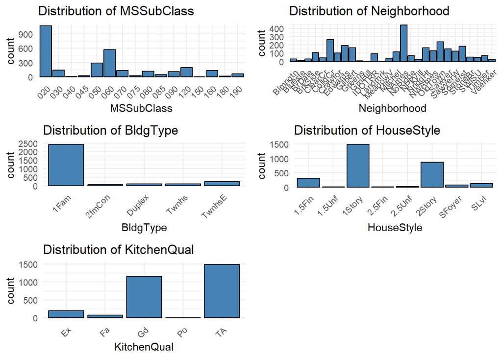

```r
# Load required libraries
library(readr)
library(ggplot2)
library(dplyr)
library(gridExtra)
# Function to plot categorical distributions
plot_categorical_distributions <- function(df, columns) {
  plots <- list()

  for (col in columns) {
    if (col %in% names(df)) {
      if (is.character(df[[col]]) || is.factor(df[[col]])) {
        p <- ggplot(df, aes_string(x = col)) +
          geom_bar(fill = "steelblue", color = "black") +
          ggtitle(paste("Distribution of", col)) +
          theme_minimal() +
          theme(axis.text.x = element_text(angle = 45, hjust = 1))
        plots[[col]] <- p
      } else {
        warning(paste("Skipping", col, "- not a categorical column."))
      }
    } else {
      warning(paste("Column", col, "not found in the data frame."))
    }
  }

  if (length(plots) == 0) {
    message("No categorical columns to plot.")
  } else {
    # Show all plots, 2 per row
    grid.arrange(grobs = plots, ncol = 2)
  }
}

# Example usage:
df <- read_csv("amesHousing2011.csv")
cat_columns <- c("MSSubClass", "Neighborhood", "BldgType", "HouseStyle", "KitchenQual")
plot_categorical_distributions(df, cat_columns)
```

```
---

### 📝 Notes:
- Rotates x-axis labels for readability.
- Skips and warns if a column isn’t found or isn’t categorical.
- Uses `gridExtra` to neatly arrange multiple plots.

Let me know if you want:
- **Percentages instead of raw counts**
- **Top N values only** (to deal with too many categories)
- To **save the plots as files** instead of displaying them
```

#### Determine Mode for Each Column

Statistics like mean, median, variance, and standard deviation cannot be calculated for categorical columns. However, we can calculate the mode, which will show which category appears the most for each column.

##### Prompt

Can you write an R script that determines the mode (or the category that shows up the most) for each categorical column?

##### Response

```
Absolutely! Here's an R script that takes a **list of categorical column names** and computes the **mode** (most frequent category) for each one.

---

### 📜 **R Script: Compute Mode for Categorical Columns**
```

```r
# Load required libraries
library(readr)
library(dplyr)

# Function to compute mode for a vector
get_mode <- function(x) {
  ux <- na.omit(unique(x))
  ux[which.max(tabulate(match(x, ux)))]
}

# Function to compute mode for each categorical column
compute_modes <- function(df, columns) {
  results <- data.frame(Column = character(), Mode = character(), stringsAsFactors = FALSE)

  for (col in columns) {
    if (col %in% names(df)) {
      if (is.character(df[[col]]) || is.factor(df[[col]])) {
        mode_value <- get_mode(df[[col]])
        results <- rbind(results, data.frame(Column = col, Mode = mode_value))
      } else {
        warning(paste("Skipping", col, "- not a categorical column."))
      }
    } else {
      warning(paste("Column", col, "not found in the data frame."))
    }
  }

  return(results)
}

# Example usage:
df <- read_csv("amesHousing2011.csv")
cat_columns <- c("MSSubClass", "Neighborhood", "BldgType", "HouseStyle", "KitchenQual")
mode_results <- compute_modes(df, cat_columns)
print(mode_results)
```

```
        Column   Mode
1   MSSubClass    020
2 Neighborhood  NAmes
3     BldgType   1Fam
4   HouseStyle 1Story
5  KitchenQual     TA
```

```
---

Let me know if you'd like it to also return **frequency counts**, **handle ties**, or **export the results**!
```

## Bivariate Analysis

Now that I have analyzed the columns, I will analyze the columns in relation to each other. Specifically, I will perform bivariate analysis, where I will look at 2 columns at a time.

### Numerical Columns

The numerical columns are: `OverallCond`, `BedroomAbvGr`, `HalfBath`, `FullBath`, `GarageArea`, `GrLivArea`, `TotalBsmtSF`, `PoolArea`, and `YearBuilt`.

#### Determining Correlation Coefficient and Covariance

I will start by determining the correlation coefficient between pairs of columns. This can help me analyze how 2 columns may relate to each other. I will also include the `SalePrice` column to see if any feature columns have any interesting relationships with the `SalePrice` column.

##### Prompt

Can you write an R script that takes an input list of columns, and outputs the correlation coefficient between all column pairs?

##### Response

```
Definitely! Here's an R script that:

- Takes a list of **numeric column names**
- Computes the **correlation coefficient** (Pearson, by default) for **all pairs** of those columns
- Outputs the results in a **correlation matrix**

---

### 📜 **R Script: Correlation Matrix for Selected Columns**
```

```r
# Load required libraries
library(readr)
library(dplyr)

# Function to compute correlation matrix
compute_correlation_matrix <- function(df, columns, method = "pearson") {
  # Filter numeric columns only
  numeric_cols <- columns[sapply(df[columns], is.numeric)]

  if (length(numeric_cols) < 2) {
    stop("Need at least two numeric columns for correlation analysis.")
  }

  # Subset the data and drop rows with NAs
  data_subset <- df %>%
    select(all_of(numeric_cols)) %>%
    na.omit()

  # Compute correlation matrix
  cor_matrix <- cor(data_subset, method = method)
  return(cor_matrix)
}

# Example usage:
df <- read_csv("amesHousing2011.csv")
selected_columns <- c("OverallCond", "BedroomAbvGr", "HalfBath", "FullBath", "GarageArea", "GrLivArea", "TotalBsmtSF", "PoolArea", "YearBuilt", "SalePrice")
cor_matrix <- compute_correlation_matrix(df, selected_columns)
print(cor_matrix)
```

```
             OverallCond BedroomAbvGr    HalfBath    FullBath  GarageArea
OverallCond   1.00000000  -0.00577839 -0.08717934 -0.21410364 -0.15276817
BedroomAbvGr -0.00577839   1.00000000  0.24657581  0.35848767  0.07305734
HalfBath     -0.08717934   0.24657581  1.00000000  0.15653495  0.17413984
FullBath     -0.21410364   0.35848767  0.15653495  1.00000000  0.40480217
GarageArea   -0.15276817   0.07305734  0.17413984  0.40480217  1.00000000
GrLivArea    -0.11579363   0.53402743  0.43764660  0.63729338  0.47570825
TotalBsmtSF  -0.17680317   0.05375509 -0.07203019  0.32570198  0.47621086
PoolArea     -0.01271344   0.03088948 -0.01153245  0.01189442  0.02677408
YearBuilt    -0.36826824  -0.05589039  0.26726365  0.46901752  0.47882379
SalePrice    -0.10273926   0.13940196  0.28417169  0.54445899  0.64819927
               GrLivArea  TotalBsmtSF     PoolArea    YearBuilt   SalePrice
OverallCond  -0.11579363 -0.176803168 -0.012713444 -0.368268237 -0.10273926
BedroomAbvGr  0.53402743  0.053755090  0.030889481 -0.055890387  0.13940196
HalfBath      0.43764660 -0.072030188 -0.011532449  0.267263650  0.28417169
FullBath      0.63729338  0.325701977  0.011894419  0.469017525  0.54445899
GarageArea    0.47570825  0.476210861  0.026774082  0.478823794  0.64819927
GrLivArea     1.00000000  0.400924954  0.075355620  0.239542915  0.71947446
TotalBsmtSF   0.40092495  1.000000000  0.004062416  0.414413452  0.65863029
PoolArea      0.07535562  0.004062416  1.000000000 -0.008283167  0.03546966
YearBuilt     0.23954292  0.414413452 -0.008283167  1.000000000  0.56502454
SalePrice     0.71947446  0.658630292  0.035469656  0.565024537  1.00000000
```

```
---

### 🔍 Bonus (Visual Option):
To visualize the matrix:
```

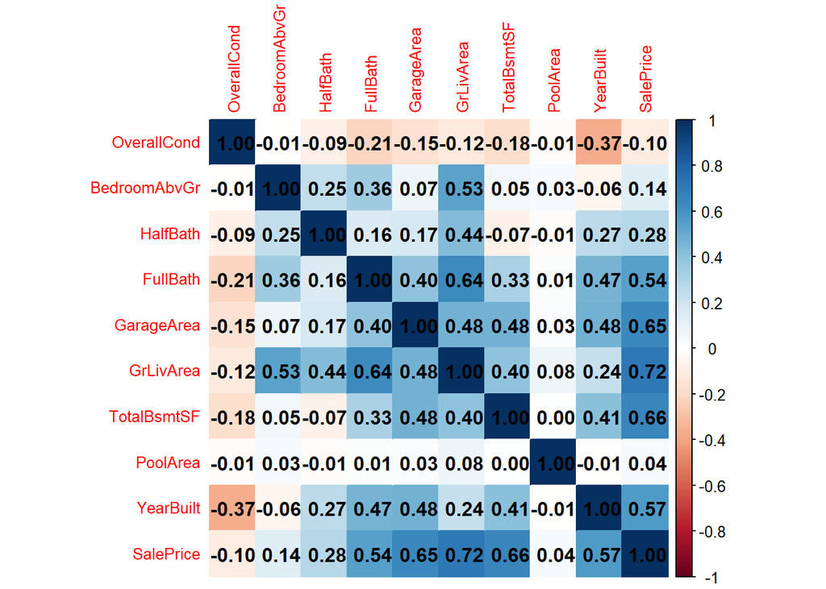

```r
# Optional: Visualize correlation matrix
library(corrplot)
corrplot(cor_matrix, method = "color", addCoef.col = "black", tl.cex = 0.8)
```

The result above shows me that certain columns, such as `YearBuilt` and `OverallCond` are negatively correlated. This makes sense as older houses are typically in worse conditions. However, `GrLivArea` and `FullBath` are positively correlated. This also makes sense as houses that have a larger living area have more bathrooms.

The results also show that `GrLivArea` is highly correlated with `SalePrice`, which makes sense. Larger homes are typically more expensive. This indicates that `GrLivArea` may be a good variable in helping determining `SalePrice` in the regression model.

#### Function to get variance and correlation information

The following function can be used to get the distribution of values for 2 columns. Additionally, it will also show the correlation coefficient and the scatter plot visualization of the correlation between 2 columns.

##### Prompt

Can you write me an R script that takes 2 column names, and uses the `ggpairs` function to show distribution and correlation information between those 2 columns?

##### Response

```
Absolutely! The `ggpairs` function from the `GGally` package is perfect for visualizing **distributions, scatterplots, and correlations** between variables — even for just two columns.

Here’s an R script that:
- Takes **two column names** as input
- Uses `ggpairs()` to generate the plot showing their **distributions**, **scatterplot**, and **correlation**

---

### 📜 **R Script: Visualize 2 Columns with `ggpairs`**
```

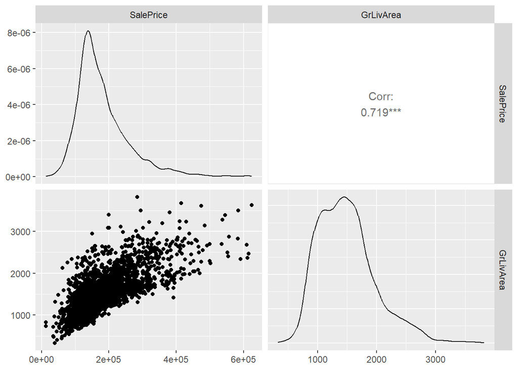

```r
# Load required libraries
library(readr)
library(GGally)
library(dplyr)

# Function to plot ggpairs for two columns
plot_ggpairs_two_columns <- function(df, col1, col2) {
  # Check if both columns exist and are numeric
  if (!(col1 %in% names(df)) || !(col2 %in% names(df))) {
    stop("One or both column names are not in the dataframe.")
  }

  if (!(is.numeric(df[[col1]]) && is.numeric(df[[col2]]))) {
    stop("Both columns must be numeric.")
  }

  # Subset and remove rows with NA
  data_subset <- df %>% select(all_of(c(col1, col2))) %>% na.omit()

  # Plot with ggpairs
  ggpairs(data_subset)
}

# Example usage:
df <- read_csv("amesHousing2011.csv")
plot_ggpairs_two_columns(df, "SalePrice", "GrLivArea")
```

```
---

### 📝 Output:
- A 2x2 matrix of plots:
  - Diagonals: histograms or density plots
  - Lower triangle: scatterplot
  - Upper triangle: correlation coefficient

Let me know if you'd like to support **non-numeric (categorical)** columns or want a version that handles **more than 2 columns**!
```

The `ggpairs` function is useful. For example, when comparing `SalePrice` and `GrLivArea`, we see that the correlation coefficient is `0.719` (similar to what we saw in the heatmap) and the scatter plot shows that the 2 columns are positively correlated with each other. This can be used to determine the importance of `GrLivArea` in helping predict the `SalePrice`.

Any 2 columns can be compared by changing the column names passed to the `plot_ggpairs_two_columns()` function.

### Categorial Columns

The categorical columns are: `MSSubClass`, `Neighborhood`, `BldgType`, `HouseStyle`, and `KitchenQual`.

#### Distribution

I will analyze the categorical columns by generating cross tabulations between categorical columns. This can show how often combinations of values occur.

##### Prompt

Can you write a R script that takes a list of categorical columns, and generates a cross tabulation between every pair?

##### Response

```
Absolutely! Here's an R script that:

- Takes a **list of categorical column names**
- Computes **cross tabulations** (contingency tables) between **every pair of columns**
- Outputs them as a list of tables, or prints each one clearly with labels

---

### 📜 **R Script: Cross Tabulation for Categorical Column Pairs**
```

```r
# Load required libraries
library(readr)

# Function to generate cross tabulations for each unique pair of categorical columns
generate_cross_tabs <- function(df, columns) {
  # Filter to only columns that exist and are categorical
  valid_cols <- columns[columns %in% names(df) & sapply(df[columns], function(x) is.factor(x) || is.character(x))]

  if (length(valid_cols) < 2) {
    stop("Need at least two valid categorical columns.")
  }

  tab_list <- list()

  for (i in 1:(length(valid_cols) - 1)) {
    for (j in (i + 1):length(valid_cols)) {
      col1 <- valid_cols[i]
      col2 <- valid_cols[j]

      tab <- table(df[[col1]], df[[col2]])
      tab_name <- paste(col1, "vs", col2)
      cat("\n============================\n")
      cat("Cross-tabulation:", tab_name, "\n")
      print(tab)

      tab_list[[tab_name]] <- tab
    }
  }

  return(tab_list)
}

# Example usage:
df <- read_csv("amesHousing2011.csv")
cat_columns <- c("MSSubClass", "Neighborhood", "BldgType", "HouseStyle", "KitchenQual")
cross_tabs <- generate_cross_tabs(df, cat_columns)
```

```
============================
Cross-tabulation: MSSubClass vs Neighborhood

      Blmngtn Blueste BrDale BrkSide ClearCr CollgCr Crawfor Edwards Gilbert
  020       3       0      0       6      18     145      24      70      24
  030       0       0      0      24       0       0       6      18       0
  040       0       0      0       2       1       0       0       1       0
  045       0       0      0       6       0       0       1       0       0
  050       0       0      0      55       7       0      21      39       1
  060       0       0      0       0       9      98       1       8     119
  070       0       0      0      11       1       0      31       5       0
  075       0       0      0       2       0       0       1       1       0
  080       0       0      0       0       4       6       2       9      19
  085       0       0      0       0       0       4       0       4       0
  090       0       0      0       0       0       1       4      18       0
  120      25       3      0       0       2      13      10       2       0
  150       0       0      0       0       1       0       0       0       0
  160       0       7     30       0       0       0       0       5       0
  180       0       0      0       0       0       0       0       6       0
  190       0       0      0       2       1       0       2       5       2

      Greens GrnHill IDOTRR Landmrk MeadowV Mitchel NAmes NoRidge NPkVill
  020      0       0      4       0       0      54   295       8       0
  030      0       0     29       0       0       0     5       0       0
  040      0       0      0       0       0       0     1       0       0
  045      0       0      2       0       0       0     4       0       0
  050      0       0     33       0       0       4    29       2       0
  060      0       0      1       0       0      11    26      58       0
  070      0       0     12       0       0       0     2       0       0
  075      0       0      1       0       0       0     1       1       0
  080      0       0      2       0       0      10    30       0       0
  085      0       0      1       0       0      13     8       0       0
  090      0       0      1       0       0      15    32       0       0
  120      8       2      0       0       4       6     6       0      11
  150      0       0      0       0       0       0     0       0       0
  160      0       0      0       1      22       0     0       0      12
  180      0       0      0       0      11       0     0       0       0
  190      0       0      7       0       0       1     4       0       0

      NridgHt NWAmes OldTown Sawyer SawyerW Somerst StoneBr SWISU Timber
```

[output cut: 214 more lines]

```
  Twnhs     2    0   39    0   60
  TwnhsE   29    0  147    0   57

============================
Cross-tabulation: HouseStyle vs KitchenQual

          Ex  Fa  Gd  Po  TA
  1.5Fin   4  18  62   1 229
  1.5Unf   0   2   4   0  13
  1Story 121  37 567   0 755
  2.5Fin   1   1   2   0   4
  2.5Unf   0   1   8   0  15
  2Story  70  11 463   0 325
  SFoyer   2   0  17   0  64
  SLvl     2   0  37   0  89
```

```
---

### 📝 Output:
- Prints each table with clear labels like `Neighborhood vs HouseStyle`
- Also stores all tables in a named list (`cross_tabs`) for later use
```

The results indicate that some combinations occur more frequently than others. For instance, when examining `HouseStyle` in relation to `KitchenQual`, houses with a `1Story` style are more likely to have kitchens in `TA` condition (typical or average). In contrast, `2Story` houses more commonly have kitchens rated as `Gd` (good) rather than `TA`.

# Step two: Inferences about the determinants of the sale price

Now that I have analyzed the numerical columns and categorical columns using univariate and bivariate analysis, I will move on to using regression analysis to draw inferences about the determinants of the sale price.

## Initial Model

### Prompt

Here are the numerical columns of interest: `OverallCond`, `BedroomAbvGr`, `HalfBath`, `FullBath`, `GarageArea`, `GrLivArea`, `TotalBsmtSF`, `PoolArea`, and `YearBuilt`. Here are the categorical columns of interest: `MSSubClass`, `Neighborhood`, `BldgType`, `HouseStyle`, and `KitchenQual`.

I know that not all of the columns are important in helping determine the target `SalePrice`. I want you to write a R script that helps me make inferences about the determinants of the sale price of a house. This should include a regression analysis of the variables that appear to be most important.

You should use the `lm()` function in R to form a regression model.

Remember to account for the fact that some columns are numerical and some are categorical. For the categorical columns, you should use indicator variables.

The output of the R script should show the regression summary.

### Response

```
Absolutely — let’s build a clean R script that helps you **analyze which features most influence `SalePrice`** using linear regression.

We will:
- Use **`lm()`** to build a multiple linear regression model
- Treat categorical variables as **factors** so R automatically creates dummy (indicator) variables
- Print the **regression summary** to see which variables are significant predictors

---

### 📜 **R Script: Regression Analysis for `SalePrice`**
```

```r
# Load necessary libraries
library(readr)
library(dplyr)

# Load the dataset
df <- read_csv("amesHousing2011.csv")
# Define numerical and categorical columns of interest
numerical_columns <- c("OverallCond", "BedroomAbvGr", "HalfBath", "FullBath", "GarageArea", "GrLivArea", "TotalBsmtSF", "PoolArea", "YearBuilt")

categorical_columns <- c("MSSubClass", "Neighborhood", "BldgType", "HouseStyle", "KitchenQual")

# Convert categorical columns to factors
df <- df %>%
  mutate(across(all_of(categorical_columns), as.factor))

# Select only relevant columns + SalePrice
model_data <- df %>%
  select(SalePrice, all_of(numerical_columns), all_of(categorical_columns)) %>%
  na.omit()  # Remove rows with NA

# Build the formula: SalePrice ~ all predictors
formula_string <- paste("SalePrice ~", paste(c(numerical_columns, categorical_columns), collapse = " + "))
regression_formula <- as.formula(formula_string)

# Fit the regression model
model <- lm(regression_formula, data = model_data)

# Output the regression summary
summary(model)
```

```
Call:
lm(formula = regression_formula, data = model_data)

Residuals:
    Min      1Q  Median      3Q     Max
-146132  -13705    -352   12870  203786

Coefficients: (1 not defined because of singularities)
                      Estimate Std. Error t value Pr(>|t|)
(Intercept)         -1.338e+06  9.612e+04 -13.918  < 2e-16 ***
OverallCond          8.475e+03  5.130e+02  16.518  < 2e-16 ***
BedroomAbvGr        -1.019e+04  8.906e+02 -11.444  < 2e-16 ***
HalfBath             3.866e+03  1.517e+03   2.548 0.010883 *
FullBath             1.986e+03  1.556e+03   1.276 0.202092
GarageArea           3.225e+01  3.210e+00  10.048  < 2e-16 ***
GrLivArea            7.487e+01  2.362e+00  31.698  < 2e-16 ***
TotalBsmtSF          3.594e+01  1.942e+00  18.510  < 2e-16 ***
PoolArea             1.337e+01  1.534e+01   0.872 0.383512
YearBuilt            6.989e+02  4.794e+01  14.580  < 2e-16 ***
MSSubClass030        7.926e+03  3.259e+03   2.432 0.015080 *
MSSubClass040        5.019e+03  1.109e+04   0.452 0.651033
MSSubClass045        2.117e+04  1.333e+04   1.588 0.112315
MSSubClass050        7.131e+03  6.086e+03   1.172 0.241413
MSSubClass060        1.311e+02  5.148e+03   0.025 0.979682
MSSubClass070        1.421e+04  5.561e+03   2.556 0.010639 *
MSSubClass075        1.657e+04  9.946e+03   1.666 0.095784 .
MSSubClass080       -1.596e+04  1.016e+04  -1.572 0.116101
MSSubClass085       -9.355e+03  7.288e+03  -1.284 0.199413
MSSubClass090       -2.669e+04  3.567e+03  -7.483 9.60e-14 ***
MSSubClass120       -4.089e+04  1.051e+04  -3.890 0.000103 ***
MSSubClass150       -4.200e+04  2.992e+04  -1.404 0.160429
MSSubClass160       -4.736e+04  1.202e+04  -3.940 8.33e-05 ***
MSSubClass180       -5.293e+04  1.410e+04  -3.753 0.000178 ***
MSSubClass190       -7.254e+03  1.601e+04  -0.453 0.650434
NeighborhoodBlueste  1.733e+04  1.030e+04   1.683 0.092536 .
NeighborhoodBrDale   1.549e+04  8.339e+03   1.857 0.063399 .
NeighborhoodBrkSide -5.999e+03  6.606e+03  -0.908 0.363884
NeighborhoodClearCr  2.501e+03  6.991e+03   0.358 0.720531
NeighborhoodCollgCr -7.938e+03  5.705e+03  -1.391 0.164188
NeighborhoodCrawfor  1.725e+04  6.305e+03   2.736 0.006252 **
```

[output cut: 27 more lines]

```
HouseStyle2.5Fin    -1.566e+04  1.294e+04  -1.210 0.226269
HouseStyle2.5Unf     6.783e+03  9.396e+03   0.722 0.470426
HouseStyle2Story     3.270e+03  5.654e+03   0.578 0.563052
HouseStyleSFoyer     2.663e+04  7.816e+03   3.407 0.000666 ***
HouseStyleSLvl       2.713e+04  1.070e+04   2.537 0.011243 *
KitchenQualFa       -5.411e+04  4.276e+03 -12.655  < 2e-16 ***
KitchenQualGd       -4.864e+04  2.375e+03 -20.486  < 2e-16 ***
KitchenQualPo       -2.704e+04  2.729e+04  -0.991 0.321767
KitchenQualTA       -5.284e+04  2.672e+03 -19.778  < 2e-16 ***
---
Signif. codes:  0 '***' 0.001 '**' 0.01 '*' 0.05 '.' 0.1 ' ' 1

Residual standard error: 26590 on 2857 degrees of freedom
Multiple R-squared:  0.888, Adjusted R-squared:  0.8855
F-statistic: 348.5 on 65 and 2857 DF,  p-value: < 2.2e-16
```

```
---

### 🔍 What You’ll Get:
- **Coefficients**, **p-values**, and **R-squared**
- Insight into:
  - Which variables are significantly associated with `SalePrice`
  - The **magnitude and direction** of their effect
- Indicator variables are automatically handled for factors

---

### 📌 Notes:
- If any predictors have a **high p-value**, they might not be contributing much and could be removed in model refinement.
- To avoid multicollinearity or explore nonlinear relationships, you could later extend this with regularization (like `glmnet`) or decision trees (`randomForest`).

Let me know if you’d like help refining the model or creating diagnostic plots!
```

### Recap

The initial model `model` consists of the following columns:

- Numerical Columns: `OverallCond`, `BedroomAbvGr`, `HalfBath`, `FullBath`, `GarageArea`, `GrLivArea`, `TotalBsmtSF`, `PoolArea`, and `YearBuilt`.
- Categorical Columns: `MSSubClass`, `Neighborhood`, `BldgType`, `HouseStyle`, and `KitchenQual`.

This model has an adjusted r-squared value of 0.8855.

## Reduced Model

GPT-4o suggested that predictors that have a high p-value may not be as useful. Thus, I will ask GPT-4o to write me a script that creates a linear regression model, filters out columns that have a high p-value, and returns the remaining columns. Specifically, I will ask it to keep columns that have a p-value of less than 0.05.

### Prompt

You mentioned that some predictors may have a high p-value and may not be contributing much to the model. Can you write an R script that create the LR model, determines the p-value of all columns, and returns the set of columns that have a p-value of less than 0.05? Right now, the model has many columns (including indicator columns). I want to end with a set of columns that is significantly smaller, but can achieve a similar performance. That way, this model is more easily interpretable.

For indicator variables, even if one of the categories has a p-value of less than 0.05, then include the original categorical variable. Ensure that when you are rebuilding the model, you don’t directly input the indicator variables, but instead, use the original column names.

### Response

```
You're spot-on — simplifying your model while preserving performance improves both interpretability and generalization. Let’s build an R script that does exactly what you described.

---

### ✅ What This Script Does:
1. Builds a full linear regression model with both numerical and categorical predictors.
2. Extracts the **p-values** of all predictor terms.
3. For categorical variables (with dummy variables), keeps the **original column** if **any of its levels** is significant (p < 0.05).
4. Returns a **reduced set of predictors**.
5. Builds a new regression model using only the reduced set.

---

### 📜 **R Script: Feature Selection Based on p-values**
```

```r
# Load necessary libraries
library(readr)
library(dplyr)
library(stringr)
# Load the dataset
df <- read_csv("amesHousing2011.csv")
# Define columns
numeric_cols <- c("OverallCond", "BedroomAbvGr", "HalfBath", "FullBath", "GarageArea", "GrLivArea", "TotalBsmtSF", "PoolArea", "YearBuilt")

categorical_cols <- c("MSSubClass", "Neighborhood", "BldgType", "HouseStyle", "KitchenQual")

# Select and clean data
selected_cols <- c(numeric_cols, categorical_cols, "SalePrice")
model_data <- df %>%
  select(all_of(selected_cols)) %>%
  na.omit()

# Convert categorical variables to factors
model_data[categorical_cols] <- lapply(model_data[categorical_cols], factor)

# Create full model formula
full_formula <- as.formula(paste("SalePrice ~", paste(c(numeric_cols, categorical_cols), collapse = " + ")))

# Fit full model
full_model <- lm(full_formula, data = model_data)

# Extract summary
model_summary <- summary(full_model)

# Extract term names and p-values
coefs <- coef(model_summary)
p_values <- coefs[, "Pr(>|t|)"]
term_names <- names(p_values)

# Determine which terms have p-value < 0.05
significant_terms <- term_names[p_values < 0.05]

# Map indicator variables back to original categorical columns
sig_numeric <- intersect(numeric_cols, significant_terms)

sig_categorical <- categorical_cols[sapply(categorical_cols, function(cat_col) {
  any(str_detect(significant_terms, fixed(cat_col)))
})]

# Combine reduced set of predictors
reduced_predictors <- c(sig_numeric, sig_categorical)

# Print the reduced set
cat("✅ Reduced set of predictors (p < 0.05):\n")
```

```
✅ Reduced set of predictors (p < 0.05):
```

```r
print(reduced_predictors)
```

```
 [1] "OverallCond"  "BedroomAbvGr" "HalfBath"     "GarageArea"   "GrLivArea"
 [6] "TotalBsmtSF"  "YearBuilt"    "MSSubClass"   "Neighborhood" "HouseStyle"
[11] "KitchenQual"
```

```r
# Rebuild reduced model
reduced_formula <- as.formula(paste("SalePrice ~", paste(reduced_predictors, collapse = " + ")))
reduced_model <- lm(reduced_formula, data = model_data)

# Show summary of the reduced model
cat("\n📉 Summary of reduced model:\n")
```

```
📉 Summary of reduced model:
```

```r
summary(reduced_model)
```

```
Call:
lm(formula = reduced_formula, data = model_data)

Residuals:
    Min      1Q  Median      3Q     Max
-145762  -13562    -309   12858  204171

Coefficients:
                      Estimate Std. Error t value Pr(>|t|)
(Intercept)         -1.358e+06  9.459e+04 -14.352  < 2e-16 ***
OverallCond          8.409e+03  5.128e+02  16.398  < 2e-16 ***
BedroomAbvGr        -1.005e+04  8.850e+02 -11.356  < 2e-16 ***
HalfBath             3.006e+03  1.404e+03   2.141 0.032325 *
GarageArea           3.275e+01  3.209e+00  10.205  < 2e-16 ***
GrLivArea            7.622e+01  2.138e+00  35.654  < 2e-16 ***
TotalBsmtSF          3.563e+01  1.934e+00  18.424  < 2e-16 ***
YearBuilt            7.106e+02  4.703e+01  15.111  < 2e-16 ***
MSSubClass030        8.166e+03  3.247e+03   2.515 0.011953 *
MSSubClass040        5.070e+03  1.110e+04   0.457 0.647987
MSSubClass045        2.126e+04  1.333e+04   1.594 0.111013
MSSubClass050        6.840e+03  6.076e+03   1.126 0.260343
MSSubClass060       -1.425e+02  5.153e+03  -0.028 0.977945
MSSubClass070        1.374e+04  5.555e+03   2.474 0.013430 *
MSSubClass075        1.631e+04  9.816e+03   1.662 0.096722 .
MSSubClass080       -1.385e+04  1.013e+04  -1.368 0.171499
MSSubClass085       -9.068e+03  7.278e+03  -1.246 0.212882
MSSubClass090       -2.606e+04  3.501e+03  -7.443 1.30e-13 ***
MSSubClass120       -2.791e+04  2.681e+03 -10.409  < 2e-16 ***
MSSubClass150       -3.706e+04  2.764e+04  -1.341 0.180061
MSSubClass160       -3.795e+04  6.153e+03  -6.167 7.92e-10 ***
MSSubClass180       -4.305e+04  9.597e+03  -4.486 7.55e-06 ***
MSSubClass190       -1.942e+02  4.895e+03  -0.040 0.968354
NeighborhoodBlueste  1.376e+04  1.023e+04   1.345 0.178838
NeighborhoodBrDale   1.022e+04  8.144e+03   1.255 0.209531
NeighborhoodBrkSide -7.298e+03  6.593e+03  -1.107 0.268371
NeighborhoodClearCr  3.860e+02  6.938e+03   0.056 0.955635
NeighborhoodCollgCr -9.032e+03  5.699e+03  -1.585 0.113142
NeighborhoodCrawfor  1.615e+04  6.298e+03   2.564 0.010388 *
NeighborhoodEdwards -1.126e+04  6.071e+03  -1.855 0.063725 .
NeighborhoodGilbert -9.952e+03  5.961e+03  -1.669 0.095140 .
```

[output cut: 21 more lines]

```
HouseStyle2.5Fin    -1.647e+04  1.290e+04  -1.277 0.201677
HouseStyle2.5Unf     7.413e+03  9.306e+03   0.797 0.425765
HouseStyle2Story     3.442e+03  5.654e+03   0.609 0.542698
HouseStyleSFoyer     2.569e+04  7.780e+03   3.302 0.000970 ***
HouseStyleSLvl       2.497e+04  1.067e+04   2.341 0.019324 *
KitchenQualFa       -5.450e+04  4.276e+03 -12.746  < 2e-16 ***
KitchenQualGd       -4.891e+04  2.364e+03 -20.687  < 2e-16 ***
KitchenQualPo       -2.618e+04  2.731e+04  -0.959 0.337710
KitchenQualTA       -5.332e+04  2.668e+03 -19.982  < 2e-16 ***
---
Signif. codes:  0 '***' 0.001 '**' 0.01 '*' 0.05 '.' 0.1 ' ' 1

Residual standard error: 26620 on 2862 degrees of freedom
Multiple R-squared:  0.8876,    Adjusted R-squared:  0.8852
F-statistic: 376.5 on 60 and 2862 DF,  p-value: < 2.2e-16
```

```
---

### 🧠 Why This Is Good:
- Keeps your model **interpretable**.
- Avoids manually inspecting dozens of dummy variables.
- Uses **statistical significance (p < 0.05)** as a filter.
- Easily extendable for interaction terms or stepwise modeling later.

---

Let me know if you'd like to also compare the performance (like R² or RMSE) of the reduced vs full model, or visualize residuals!
```

### Recap

The reduced model `reduced_model` consists of the following columns:

- Numerical Columns: `OverallCond`, `BedroomAbvGr`, `HalfBath`, `GarageArea`, `GrLivArea`, `TotalBsmtSF`, and `YearBuilt`.
- Categorical Columns: `MSSubClass`, `Neighborhood`, `HouseStyle`, and `KitchenQual`.

This model has an adjusted r-squared value of 0.8852.

The performance of this model (`reduced_model`) is very similar to that of `model`.

## Further Reduced Model

### Prompt

I would like to further simplify the model. Can you modify the previous script such that it sorts the columns by p-value and then returns the 5 columns with the least p-values?

### Response

```
Absolutely! Here's an updated version of the previous script that:

1. **Builds the full regression model**
2. Extracts **p-values** for each predictor term
3. Maps significant **indicator variables back to original columns**
4. Sorts variables by **lowest p-value**
5. Returns a set of the **top 5 predictors** based on lowest p-value
6. Builds a reduced model using just those 5 predictors (categorical handled correctly)

---

### 📜 **R Script: Select Top 5 Predictors with Lowest p-values**
```

```r
# Load required libraries
library(readr)
library(dplyr)
library(stringr)

# Load the dataset
df <- read_csv("amesHousing2011.csv")
# Define columns
numeric_cols <- c("OverallCond", "BedroomAbvGr", "HalfBath", "FullBath", "GarageArea", "GrLivArea", "TotalBsmtSF", "PoolArea", "YearBuilt")

categorical_cols <- c("MSSubClass", "Neighborhood", "BldgType", "HouseStyle", "KitchenQual")

# Select and clean data
selected_cols <- c(numeric_cols, categorical_cols, "SalePrice")
model_data <- df %>%
  select(all_of(selected_cols)) %>%
  na.omit()

# Convert categorical variables to factors
model_data[categorical_cols] <- lapply(model_data[categorical_cols], factor)

# Build full model
full_formula <- as.formula(paste("SalePrice ~", paste(c(numeric_cols, categorical_cols), collapse = " + ")))
full_model <- lm(full_formula, data = model_data)
model_summary <- summary(full_model)

# Extract coefficients and p-values
coefs <- coef(model_summary)
p_values <- coefs[, "Pr(>|t|)"]
term_names <- names(p_values)

# Remove intercept
term_names <- term_names[term_names != "(Intercept)"]
p_values <- p_values[names(p_values) != "(Intercept)"]

# Create a data frame of term and p-value
pval_df <- data.frame(term = term_names, p_value = p_values, stringsAsFactors = FALSE)

# Map indicator terms back to original variables
map_to_original <- function(term) {
  for (cat in categorical_cols) {
    if (str_detect(term, fixed(cat))) return(cat)
  }
  return(term)
}

pval_df$original_var <- sapply(pval_df$term, map_to_original)

# For each original variable, take the smallest p-value of its indicators
reduced_df <- pval_df %>%
  group_by(original_var) %>%
  summarise(min_p = min(p_value)) %>%
  arrange(min_p)

# Select top 5 variables
top5_vars <- head(reduced_df$original_var, 5)

cat("🔍 Top 5 predictors by lowest p-value:\n")
```

```
🔍 Top 5 predictors by lowest p-value:
```

```r
print(top5_vars)
```

```
[1] "GrLivArea"   "KitchenQual" "TotalBsmtSF" "OverallCond" "YearBuilt"
```

```r
# Build reduced model
reduced_formula <- as.formula(paste("SalePrice ~", paste(top5_vars, collapse = " + ")))
reduced_model_5 <- lm(reduced_formula, data = model_data)

cat("\n📉 Summary of reduced model with top 5 predictors:\n")
```

```
📉 Summary of reduced model with top 5 predictors:
```

```r
summary(reduced_model_5)
```

```
Call:
lm(formula = reduced_formula, data = model_data)

Residuals:
    Min      1Q  Median      3Q     Max
-181722  -16633    -739   14377  244546

Coefficients:
                Estimate Std. Error t value Pr(>|t|)
(Intercept)   -1.445e+06  5.486e+04 -26.346   <2e-16 ***
GrLivArea      7.340e+01  1.425e+00  51.510   <2e-16 ***
KitchenQualFa -8.327e+04  4.980e+03 -16.720   <2e-16 ***
KitchenQualGd -6.952e+04  2.613e+03 -26.610   <2e-16 ***
KitchenQualPo -4.522e+04  3.275e+04  -1.381    0.167
KitchenQualTA -8.501e+04  2.867e+03 -29.653   <2e-16 ***
TotalBsmtSF    4.949e+01  1.715e+00  28.858   <2e-16 ***
OverallCond    8.642e+03  6.000e+02  14.405   <2e-16 ***
YearBuilt      7.554e+02  2.693e+01  28.048   <2e-16 ***
---
Signif. codes:  0 '***' 0.001 '**' 0.01 '*' 0.05 '.' 0.1 ' ' 1

Residual standard error: 32500 on 2914 degrees of freedom
Multiple R-squared:  0.8293,    Adjusted R-squared:  0.8289
F-statistic:  1770 on 8 and 2914 DF,  p-value: < 2.2e-16
```

```
---

### ✅ Output:
- Prints the **5 most statistically significant predictors**
- Builds and summarizes a reduced regression model with those 5 predictors

---

Let me know if you’d like to:
- Compare model performance (e.g. R², RMSE)
- Visualize residuals
- Export the model or use it for predictions
```

### Recap

The reduced model `reduced_model_5` consists of the following columns:

- Numerical Columns: `OverallCond`, `GrLivArea`, `TotalBsmtSF`, and `YearBuilt`.
- Categorical Columns: `KitchenQual`.

This model has an adjusted r-squared value of 0.8289.

The performance of this model (`reduced_model_5`) is noticably lower than that of `reduced_model`.

## Analysis

| Model | # Numerical Columns | # Categorical Columns | Multiple R-squared | Adjusted R-squared |
| --- | --- | --- | --- | --- |
| Initial | 9 | 5 | 0.888 | 0.8855 |
| Reduced (p < 0.05) | 7 | 4 | 0.8876 | 0.8852 |
| Reduced to 5 Columns | 4 | 1 | 0.8293 | 0.8289 |

The `reduced_model` has a very comparable adjusted r-squared performance compared to the initial model (`model`), while having 3 less columns. This demonstrates that more columns aren’t always better, as they result in greater overhead and lower interpretability. The reduced (and slightly more simple) model is able to achieve about the same performance with less columns. This demonstrates the power of using p-value to filter out unnecessary columns.

However, if I limit the column count to 5 (keeping only the columns with the lowest p-values), then my performance suffers quite a bit, resulting in an adjusted r-squared value of 0.8289. This demonstrates that there needs to be a balance between reducing the number of columns while capturing as much important information as possible.

# Step three: Regression diagnostics

I will now analyze the regression models that I created. To do so, I will create 4 diagnostic plots using the `plot` method.

## Diagnostic plots using `plot()` method

### Linear Regression Model: `model`

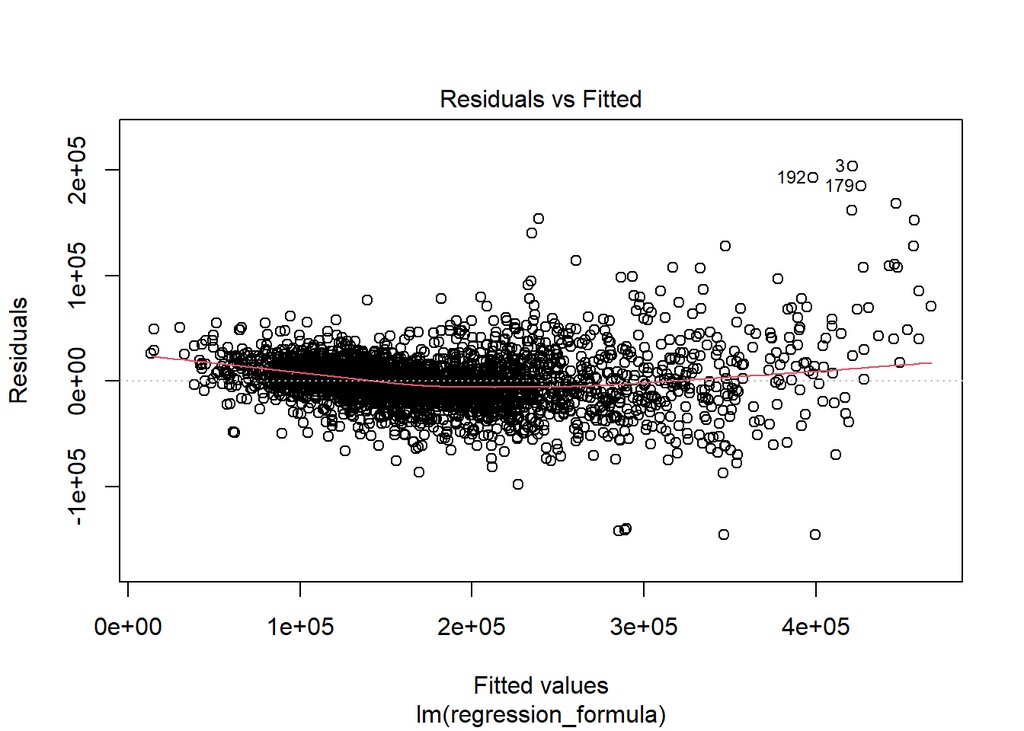

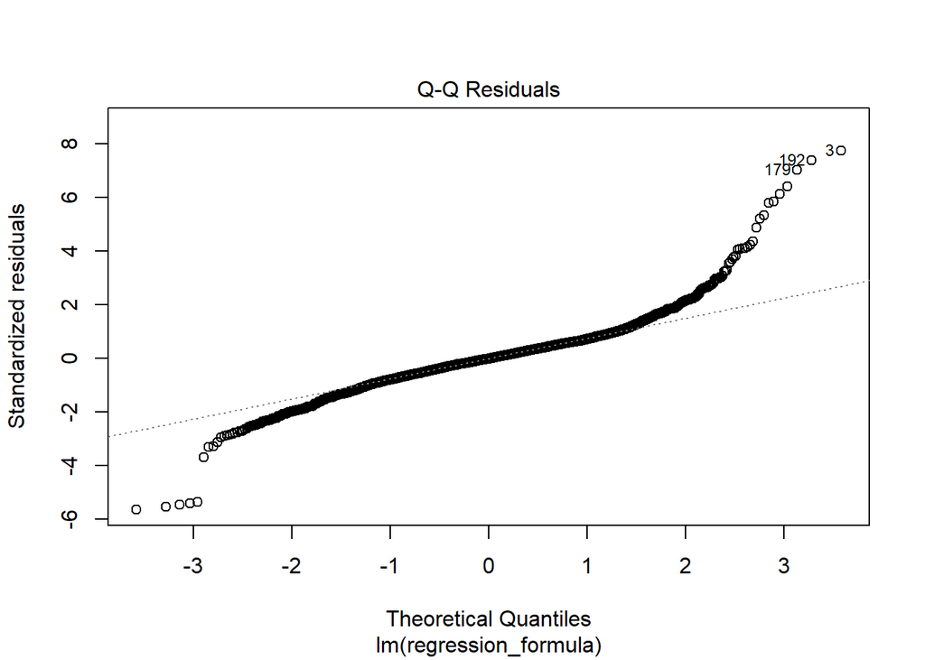

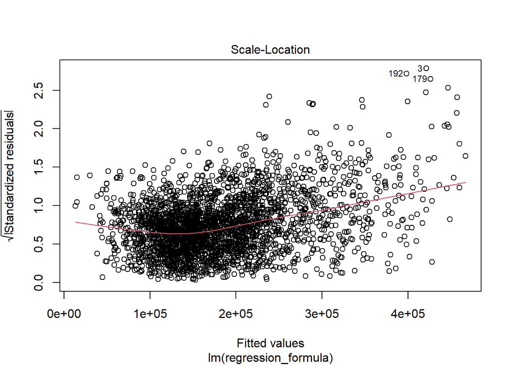

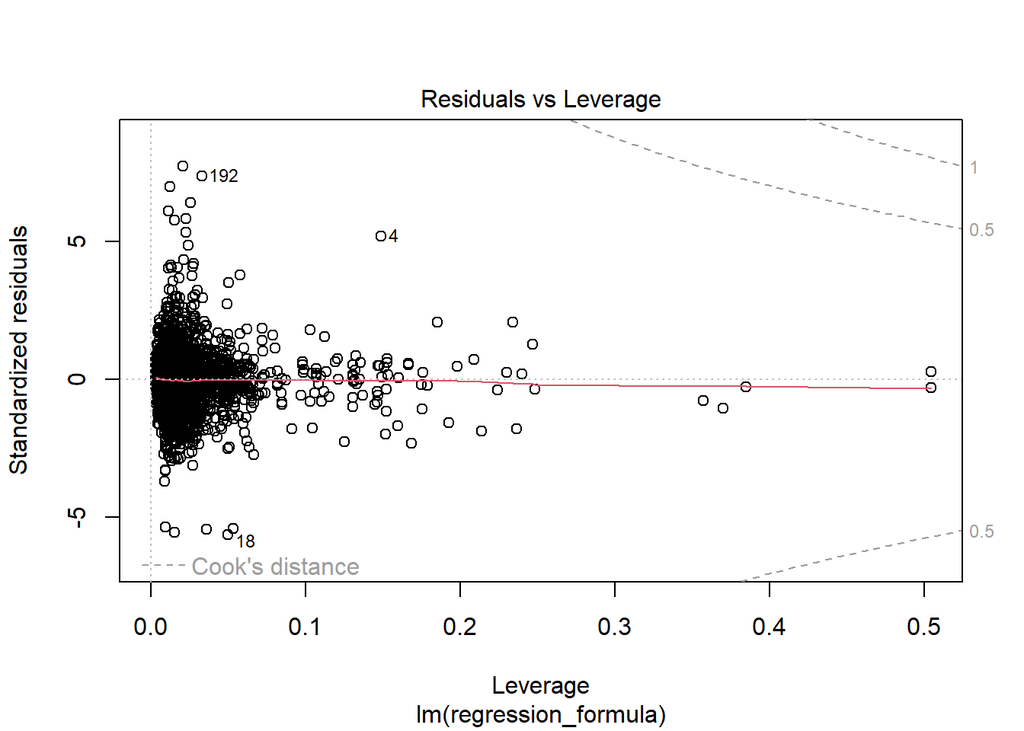

```r
plot(model)
```

### Linear Regression Model: `reduced_model`

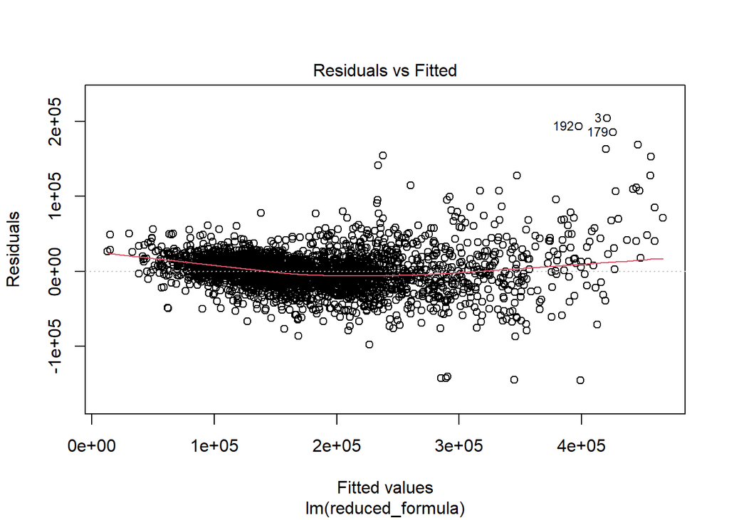

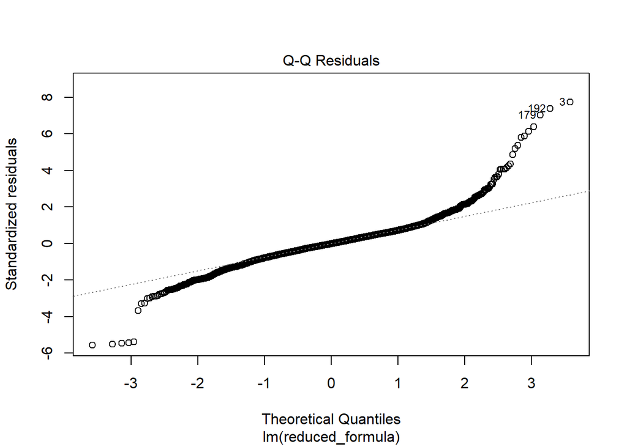

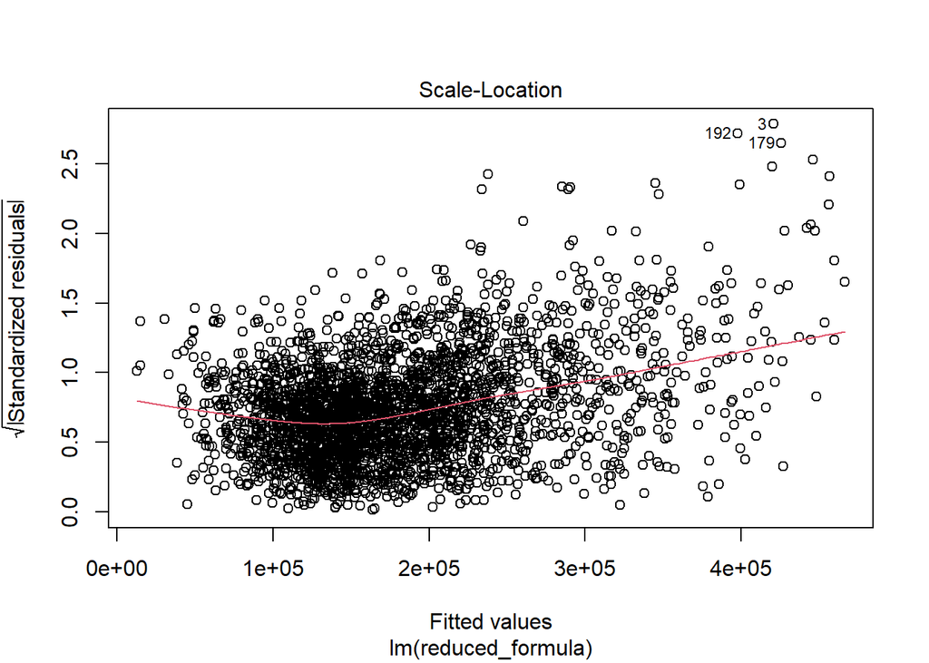

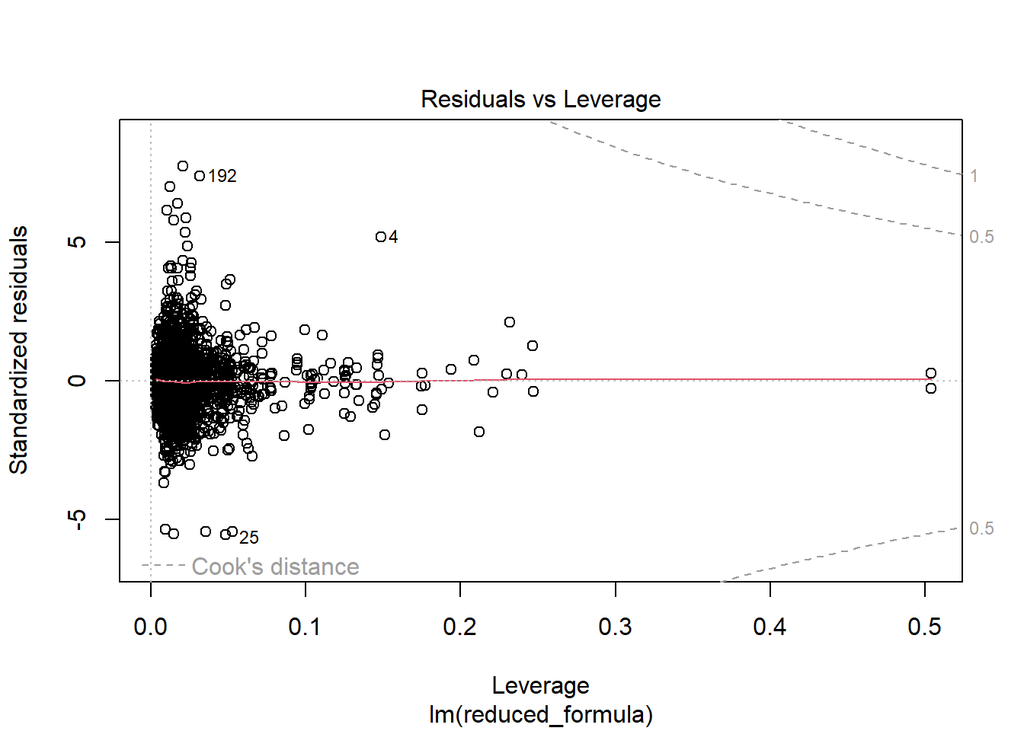

```r
plot(reduced_model)
```

### Linear Regression Model: `reduced_model_5`

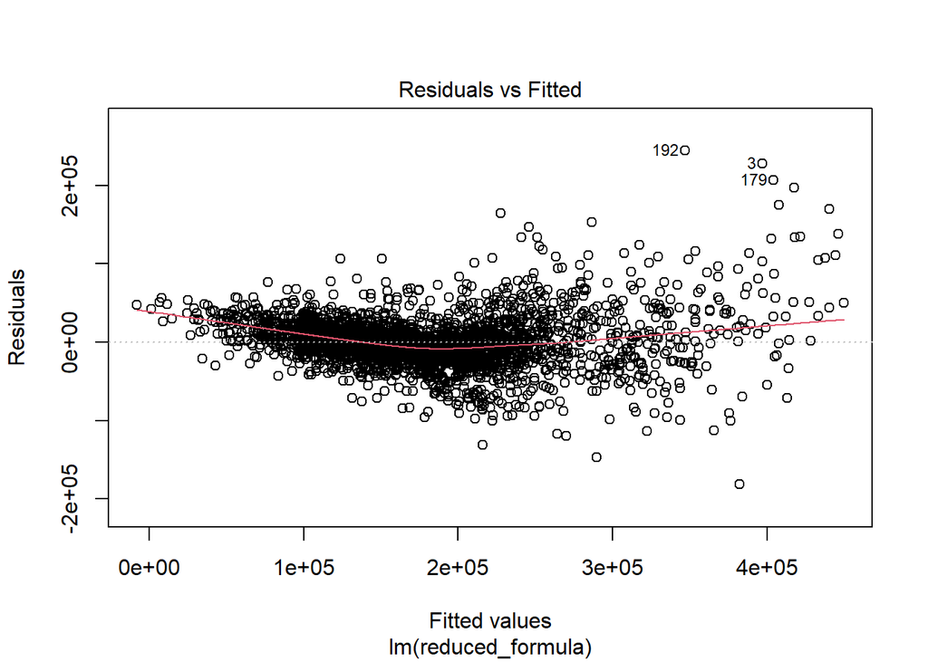

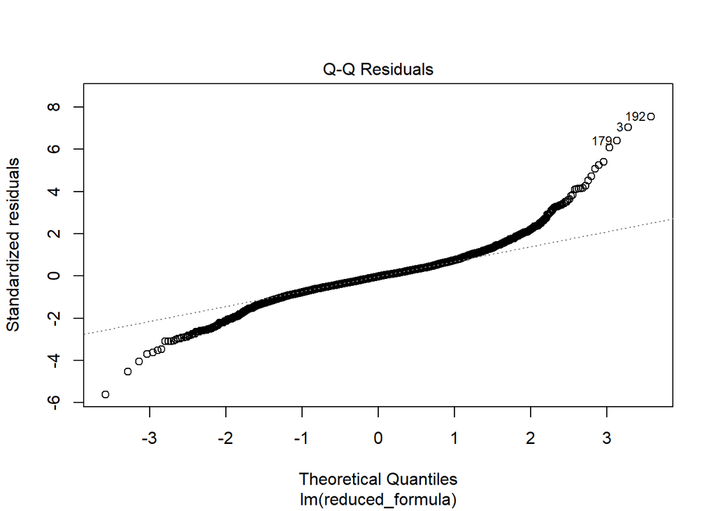

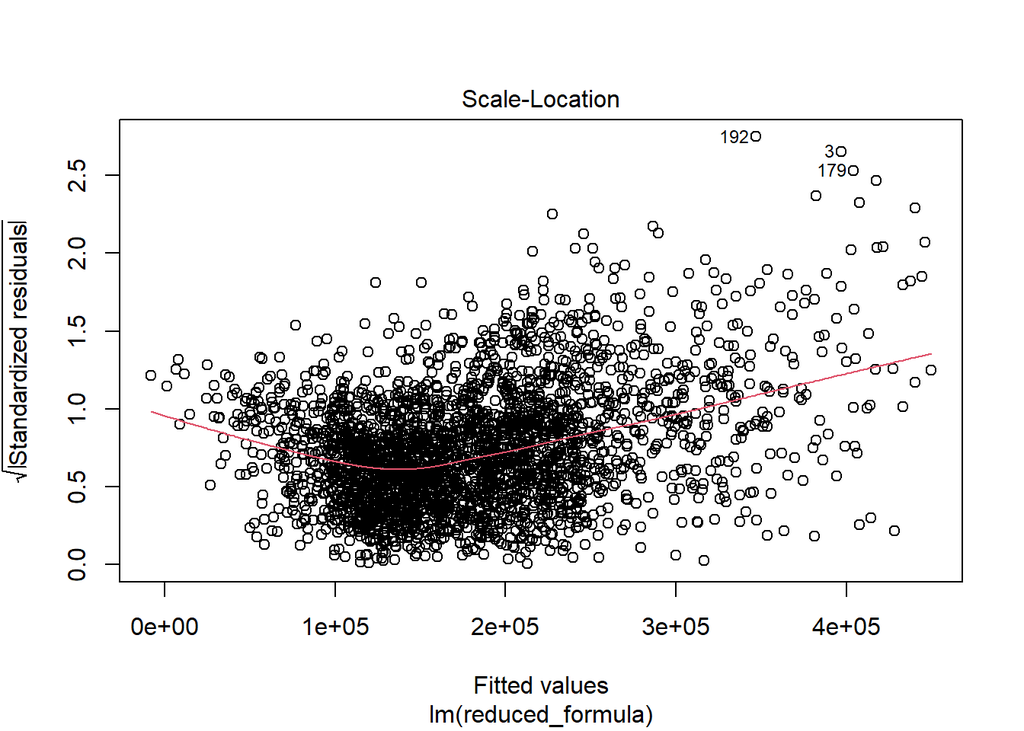

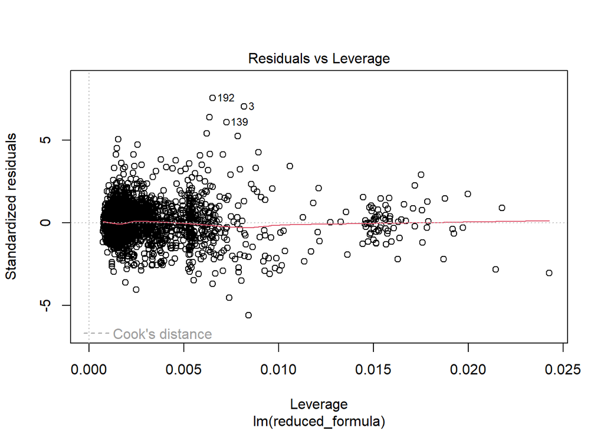

```r
plot(reduced_model_5)
```

## Custom Residual Plots - Similar to those in this [paper](https://jse.amstat.org/v19n3/decock.pdf)

The `plot` function above creates the Q-Q plot and the Residuals vs Fitted plots. However, it does not create a Histogram to show the distribution of residuals and it does not create the Residuals vs Order plot.

### Prompt

```
Can you write a function in R that takes in a Linear Regression Model as an input, and a Histogram that shows the distribution of residuals and a Residuals vs Order Plot?

### Response

Absolutely! Here's an R function that takes a **Linear Regression model object** (`lm`) and generates two important diagnostic plots:

1. **Histogram of residuals** – to check if residuals are approximately normally distributed
2. **Residuals vs Order plot** – to detect any time-based or order-based patterns (non-randomness)

---

### 📜 **R Function: Plot Residual Diagnostics**
```

```r
# Load required libraries
library(ggplot2)
library(gridExtra)

# Define the function
plot_residual_diagnostics <- function(model) {
  # Extract residuals
  residuals <- resid(model)
  obs_order <- seq_along(residuals)

  # Histogram of residuals
  hist_plot <- ggplot(data.frame(residuals), aes(x = residuals)) +
    geom_histogram(bins = 30, fill = "skyblue", color = "black", alpha = 0.7) +
    geom_vline(xintercept = 0, color = "red", linetype = "dashed") +
    labs(title = "Histogram of Residuals", x = "Residual", y = "Frequency") +
    theme_minimal()

  # Residuals vs Order
  order_plot <- ggplot(data.frame(Order = obs_order, Residual = residuals), aes(x = Order, y = Residual)) +
    geom_point(color = "darkblue", alpha = 0.6) +
    geom_hline(yintercept = 0, color = "red", linetype = "dashed") +
    labs(title = "Residuals vs Order", x = "Observation Order", y = "Residual") +
    theme_minimal()

  # Display the plots side-by-side
  grid.arrange(hist_plot, order_plot, ncol = 2)
}

# Example usage:
# model <- lm(SalePrice ~ OverallQual + GrLivArea, data = df)
# plot_residual_diagnostics(model)
```

```
---

### 🔍 Interpretation:
- **Histogram**: Should be roughly bell-shaped if residuals are normally distributed.
- **Residuals vs Order**: Should show no clear patterns if the residuals are randomly distributed (a key regression assumption).

---

Let me know if you also want a **Residuals vs Fitted Values plot** or **Q-Q plot** to assess normality more formally!
```

### Custom Residual Plots for Linear Regression Model - `model`

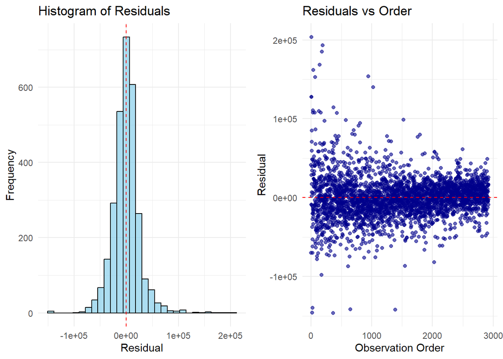

```r
plot_residual_diagnostics(model)
```

### Custom Residual Plots for Linear Regression Model - `reduced_model`

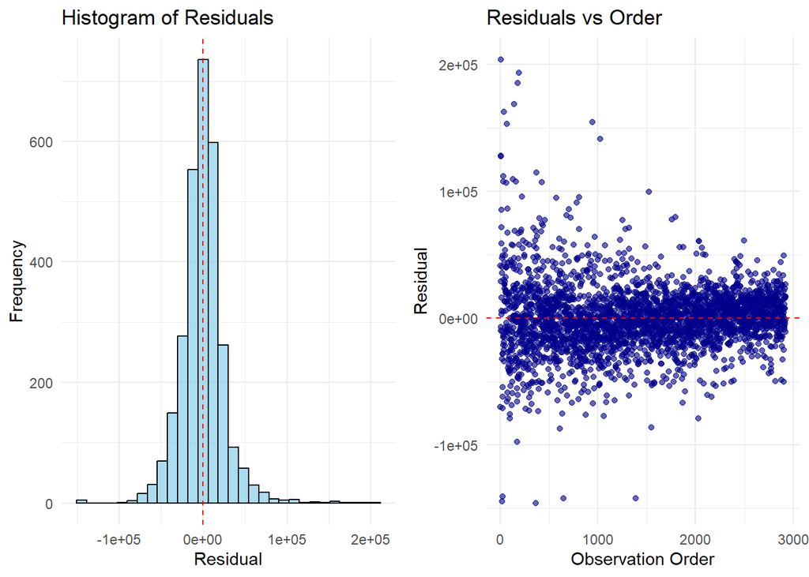

```r
plot_residual_diagnostics(reduced_model)
```

### Custom Residual Plots for Linear Regression Model - `reduced_model_5`

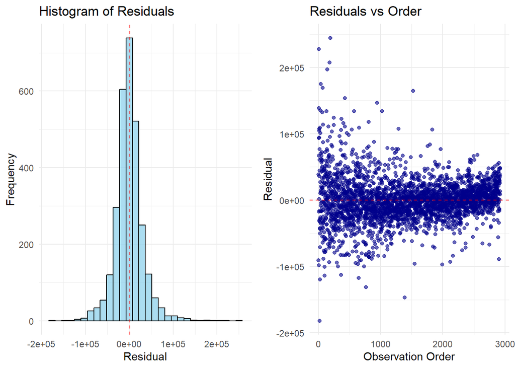

```r
plot_residual_diagnostics(reduced_model_5)
```

## Analysis of Plots

Firstly, I didn’t have prior understanding of what Scale-Location and Residuals vs Leverage plots are, so I asked GPT-4o to help me understand them:

### Prompt

Can you give me a concise understanding of Scale-Location plot and Residuals vs Leverage plot?

### Response

```
Absolutely — here’s a **concise understanding** of both:

---

### 📊 **Scale-Location Plot (a.k.a. Spread-Location Plot)**

- **X-axis:** Fitted values (predicted values from the model)
- **Y-axis:** Square root of standardized residuals
- **Purpose:** Checks if residuals have **equal spread** across all levels of predicted values
- **What you want to see:** A **horizontal line** with evenly spread points
- **Bad signs:**
  - **Fan shape** (points spread out as fitted values increase) → suggests **heteroscedasticity** (non-constant variance), which can lead to biased standard errors

✅ **Good for checking assumption**: constant variance (homoscedasticity)

---

### 📈 **Residuals vs. Leverage Plot**

- **X-axis:** Leverage (how far an observation’s values are from the mean of predictors)
- **Y-axis:** Studentized residuals
- **Purpose:** Identifies **influential observations**
- **What you want to see:** Most points close to center; no points in outer **Cook’s distance circles**
- **Bad signs:**
  - Points far to the right (high leverage) **and** far up/down (large residual) → may **distort your model**

✅ **Good for identifying dangerous outliers** that affect model fit

---

### 🧠 In 1 sentence each:
- **Scale-Location:** "Are the residuals spread out evenly across predicted values?"
- **Residuals vs Leverage:** "Are there any data points that have an outsized influence on the model?"

Let me know if you want examples or help reading one of your plots!
```

### Residuals vs Fitted Analysis

Looking at the Residuals vs Fitted plots for the three models, `model` and `reduced_model` produce similar results, with residuals showing a fairly random spread around the horizontal line at 0 —- though there is a slight convex curvature. However, the plot for `reduced_model_5` shows a slightly more pronounced convex pattern. This stronger curvature suggests a nonlinear relationship between the predictors (feature columns) and the response variable (`SalePrice`). Since linear regression assumes a linear relationship, such nonlinearity can lead to poorer model performance. This is supported by the notably lower adjusted R-squared value for `reduced_model_5` compared to both `model` and `reduced_model`.

### Q-Q Analysis

Looking at the Q-Q Residuals plot for all models, most of the the residuals fall fairly close to the line. This suggests that the bulk of the residuals are approximately normally distributed. However, both the left and right tails deviate significantly from the line. This suggests the presence of outliers, which can impact inference accuracy. This problem can be mitigated by preprocessing the data by identifying and removing outliers.

### Histogram of Residuals Analysis

Looking at the Histogram of Residuals for all models, the residuals are centered around 0, which is expected. The distribution is also symmetric and resembles the “bell-shape”. Some of the tail bins have somewhat high frequency, which aligns with what we saw in the Q-Q Residuals.

### Residuals vs Order Analysis

Finally, looking at the Residuals vs Order plots, most of the residuals are randomly scattered around 0. However, residuals earlier in the observation order seem to have a higher variance in residual (wider spread around 0), whereas the residuals later in the observation order are more tightly spread around 0. This means that the models are making bigger mistakes earlier in the dataset compared to the end. An analysis into the dataset itself may provide explanations why this is the case. Maybe the data is noisier at the start, or the dataset has a non-random order, where certain types of houses (that the model struggles with) are grouped near the beginning. A deeper look into the structure and ordering of the dataset might help explain this behavior.

# Step four: results

Considering that `model` and `reduced_model` had very similar (almost same) adjusted r-squared value, and that `reduced_model_5` had a noticable lower adjusted r-squared value, I would select the featured (columns) used for the `reduced_model` as the final list of variables that best determine the sale price. These features are `OverallCond`, `BedroomAbvGr`, `HalfBath`, `GarageArea`, `GrLivArea`, `TotalBsmtSF`, `YearBuilt`, `MSSubClass`, `Neighborhood`, `HouseStyle`, and `KitchenQual`. This constitutes a total of 11 columns. These columns were selected because they had a p-value of less than 0.05 from the original set of columns. This is still a lot of columns; however, reducing it further to 5 columns results in a significant performance drop.

It is interesting to note that even the `reduced_model_5`, which had the columns `OverallCond`,`GrLivArea`, `TotalBsmtSF`, `YearBuilt`, and `KitchenQual`, had an adjusted r-squared value of `0.8289`, which is still better than the adjusted r-squared value of `0.703` shown in Figure 5 of this [paper](https://jse.amstat.org/v19n3/decock.pdf) by Dean De Cock.

My final set of columns that best determine the sale price are `OverallCond`, `BedroomAbvGr`, `HalfBath`, `GarageArea`, `GrLivArea`, `TotalBsmtSF`, `YearBuilt`, `MSSubClass`, `Neighborhood`, `HouseStyle`, and `KitchenQual`. If I had to reduce that set to 5 columns, then I would choose `OverallCond`,`GrLivArea`, `TotalBsmtSF`, `YearBuilt`, and `KitchenQual`.

# Conclusion

In this analysis, I explored the Ames Housing Dataset with the goal of identifying the most important features (columns) that influence house `SalePrice`. I followed a structured approach that began with **exploratory data analysis (EDA)** and ended with a **refined regression model** for price prediction.

I first determined which columns to explore, as not all columns are beneficial to this task. I determined the viable columns by manually inspecting the `amesHousing2011doc.txt` and `amesHousing2011.csv` file. GPT-4o was also beneficial for this task. I uploaded the aforementioned files and asked the LLM to give me a list of columns that it deemed were important. I determined the final list by taking a union of my list and the list the GPT-4o provided.

Then, I used **univariate and bivariate analysis** to understand the distribution and relationships (such as correlation) between the features (columns) as well and the target variable, `SalePrice`. I examined both **numerical columns** (using histograms, boxplots, and correlation coefficients) and **categorical columns** (using distribution charts, cross-tabulations, and modes). This allowed me to build an intuitive understanding of the data and observe potential feature interactions.

From there, I moved on to **regression modeling** to formally assess how each variable impacts sale price. I began with a comprehensive model that included 14 variables (9 numerical and 5 categorical), then systematically reduced the number of features using **p-values** to evaluate statistical significance. The final refined model, which used 11 features, achieved nearly the same adjusted r-squared value as the model with all 14 features, demonstrating that many predictors were redundant or non-contributive. A smaller 5-variable model, while more interpretable, did show a performance drop, highlighting the need to balance simplicity and accuracy.

The final diagnostics included **residual analysis** using Q-Q plots, histograms, and residuals vs. fitted/order plots. These diagnostics confirmed that while the models generally adhered to regression assumptions, there were signs of nonlinearity and outliers, particularly in the tails of the residual distributions. This pointed to potential improvements through data preprocessing or nonlinear modeling techniques.

## Reflection on the Utility of GPT-4o

A critical part of this project was leveraging **GPT-4o** to assist throughout the entire analytical pipeline. GPT-4o provided:

- **Analytical guidance**: It helped brainstorm appropriate statistical and visual techniques tailored to the data structure.
- **Code generation**: It wrote modular, well-structured R code for tasks such as visualizing distributions, calculating statistical summaries, generating regression models, and interpreting diagnostics.
- **Model refinement**: It suggested approaches to reduce model complexity without compromising performance, such as filtering features by p-value and comparing adjusted r-squared values.
- **Plot explanation**: It offered intuitive explanations for how plots should behave in an ideal situation, such as bell-shaped curve of the histogram and random scattering for the Residuals vs Order plot.

The LLM was not just a passive tool, it acted like a **real-time statistical consultant**, significantly accelerating my workflow and reducing time spent on boilerplate code. It also encouraged deeper reflection by suggesting alternative perspectives (such as cross-tabulations for categorial data and standardized variance to account for differences in units between columns), many of which I may not have initially considered.

Overall, this project demonstrated the power of combining **human intuition and domain knowledge** with **LLM-assisted analysis**. I was able to build and refine a meaningful model, interpret results with statistical rigor, and gain deeper insights into how different housing features influence price, all while maintaining a strong degree of control and understanding throughout the process.

# Side

```r
# Load necessary libraries
library(readr)
library(dplyr)

# Load the dataset
df <- read_csv("amesHousing2011.csv")
# Define numerical and categorical columns of interest
numerical_columns <- c("GrLivArea", "YearBuilt")

categorical_columns <- c("MSSubClass", "Neighborhood", "KitchenQual", "ExterQual", "BsmtExposure")

# Convert categorical columns to factors
df <- df %>%
  mutate(across(all_of(categorical_columns), as.factor))

# Select only relevant columns + SalePrice
model_data <- df %>%
  select(SalePrice, all_of(numerical_columns), all_of(categorical_columns)) %>%
  na.omit()  # Remove rows with NA

# Build the formula: SalePrice ~ all predictors
formula_string <- paste("SalePrice ~", paste(c(numerical_columns, categorical_columns), collapse = " + "))
regression_formula <- as.formula(formula_string)

# Fit the regression model
suggested_model <- lm(regression_formula, data = model_data)

# Output the regression summary
summary(model)
```

```
Call:
lm(formula = regression_formula, data = model_data)

Residuals:
    Min      1Q  Median      3Q     Max
-146132  -13705    -352   12870  203786

Coefficients: (1 not defined because of singularities)
                      Estimate Std. Error t value Pr(>|t|)
(Intercept)         -1.338e+06  9.612e+04 -13.918  < 2e-16 ***
OverallCond          8.475e+03  5.130e+02  16.518  < 2e-16 ***
BedroomAbvGr        -1.019e+04  8.906e+02 -11.444  < 2e-16 ***
HalfBath             3.866e+03  1.517e+03   2.548 0.010883 *
FullBath             1.986e+03  1.556e+03   1.276 0.202092
GarageArea           3.225e+01  3.210e+00  10.048  < 2e-16 ***
GrLivArea            7.487e+01  2.362e+00  31.698  < 2e-16 ***
TotalBsmtSF          3.594e+01  1.942e+00  18.510  < 2e-16 ***
PoolArea             1.337e+01  1.534e+01   0.872 0.383512
YearBuilt            6.989e+02  4.794e+01  14.580  < 2e-16 ***
MSSubClass030        7.926e+03  3.259e+03   2.432 0.015080 *
MSSubClass040        5.019e+03  1.109e+04   0.452 0.651033
MSSubClass045        2.117e+04  1.333e+04   1.588 0.112315
MSSubClass050        7.131e+03  6.086e+03   1.172 0.241413
MSSubClass060        1.311e+02  5.148e+03   0.025 0.979682
MSSubClass070        1.421e+04  5.561e+03   2.556 0.010639 *
MSSubClass075        1.657e+04  9.946e+03   1.666 0.095784 .
MSSubClass080       -1.596e+04  1.016e+04  -1.572 0.116101
MSSubClass085       -9.355e+03  7.288e+03  -1.284 0.199413
MSSubClass090       -2.669e+04  3.567e+03  -7.483 9.60e-14 ***
MSSubClass120       -4.089e+04  1.051e+04  -3.890 0.000103 ***
MSSubClass150       -4.200e+04  2.992e+04  -1.404 0.160429
MSSubClass160       -4.736e+04  1.202e+04  -3.940 8.33e-05 ***
MSSubClass180       -5.293e+04  1.410e+04  -3.753 0.000178 ***
MSSubClass190       -7.254e+03  1.601e+04  -0.453 0.650434
NeighborhoodBlueste  1.733e+04  1.030e+04   1.683 0.092536 .
NeighborhoodBrDale   1.549e+04  8.339e+03   1.857 0.063399 .
NeighborhoodBrkSide -5.999e+03  6.606e+03  -0.908 0.363884
NeighborhoodClearCr  2.501e+03  6.991e+03   0.358 0.720531
NeighborhoodCollgCr -7.938e+03  5.705e+03  -1.391 0.164188
NeighborhoodCrawfor  1.725e+04  6.305e+03   2.736 0.006252 **
```

[output cut: 27 more lines]

```
HouseStyle2.5Fin    -1.566e+04  1.294e+04  -1.210 0.226269
HouseStyle2.5Unf     6.783e+03  9.396e+03   0.722 0.470426
HouseStyle2Story     3.270e+03  5.654e+03   0.578 0.563052
HouseStyleSFoyer     2.663e+04  7.816e+03   3.407 0.000666 ***
HouseStyleSLvl       2.713e+04  1.070e+04   2.537 0.011243 *
KitchenQualFa       -5.411e+04  4.276e+03 -12.655  < 2e-16 ***
KitchenQualGd       -4.864e+04  2.375e+03 -20.486  < 2e-16 ***
KitchenQualPo       -2.704e+04  2.729e+04  -0.991 0.321767
KitchenQualTA       -5.284e+04  2.672e+03 -19.778  < 2e-16 ***
---
Signif. codes:  0 '***' 0.001 '**' 0.01 '*' 0.05 '.' 0.1 ' ' 1

Residual standard error: 26590 on 2857 degrees of freedom
Multiple R-squared:  0.888, Adjusted R-squared:  0.8855
F-statistic: 348.5 on 65 and 2857 DF,  p-value: < 2.2e-16
```